# Panel Conditioning in Fixed-Effects Models: Identification and Bias Propagation

Author

Affiliation

Shoki Okubo

Department of Sociology, Toyo University

Published

September 24, 2026

Abstract

Panel conditioning, the causal effect of prior survey participation on responses, can vary with tenure. Under an additive model of cell means in period, entry cohort, and tenure, we characterize which features of the conditioning path a staggered panel identifies on its observed support, and how the unidentified component affects common panel estimators. The identified set of the path is an affine translate of the tenure projection of the cell design’s kernel, and a linear functional of the path is identified exactly when it annihilates that projection. It always contains an affine direction and, when the entry cohorts share a stride, periodic directions, which exhaust it under a connectivity condition on observed increments; second differences at that stride are then identified, and ordinary ones generally are not when the stride exceeds one. Under a recruitment condition, an interrupted schedule such as the four-eight-four rotation of the Current Population Survey (CPS) distinguishes a constant increment per interview from one per calendar month, which no equally spaced schedule can. We give support conditions for recovery under a plateau, entry-wave negative controls, or bounded cohort drift. A second set of results links identification to regression: two-way fixed effects absorb every unidentified direction, so the remaining conditioning bias is normalization-invariant and itself identified, and a two-way regression with tenure indicators corrects it under a residual-rank condition. When event time is aligned with tenure, conditioning shifts event-study coefficients by a known linear functional of the path, producing pre-trends without anticipation; bounds on identified curvature bound those shifts. Simulations verify the identities, a 19-wave Japanese panel illustrates the support calculations, and published CPS month-in-sample indices give a descriptive, not identifying, example.

Keywords

panel conditioning, identification, age-period-cohort, two-way fixed effects, event study, refreshment samples

# 1 Introduction

Panel surveys ask the same individuals the same questions repeatedly, and a long literature documents that the act of being interviewed changes later answers—*panel conditioning* (Warren and Halpern-Manners 2012; Halpern-Manners and Warren 2012; Halpern-Manners, Warren, and Torche 2017). Formal identification analysis of the phenomenon is rare: Das, Toepoel, and van Soest (2011) give one for a binary item in a two-wave design with a refreshment sample, and Feng, Hu, and Sun (2022) give one for a latent-state model of labor-force misclassification in the Current Population Survey. For the object that most of the applied literature reports—a mean path of conditioning over tenure, estimated from the cell means of a staggered panel—practitioners have long behaved as if a non-identification result existed: the U.S. Bureau of Labor Statistics normalizes month-in-sample effects to average to one; Krueger, Mas, and Niu (2017) subtitle their study of rotation group bias “Will the Real Unemployment Rate Please Stand Up?” and conclude that it remains unclear which rotation group provides the more accurate estimate (Krueger, Mas, and Niu 2017, 264); van den Brakel and Krieg (2015) estimate rotation-group bias only relative to a reference group. Each of these choices is a normalization. This paper states the result that forces it, proves it on the panel’s observed cohort–period support, characterizes what it leaves identified—which depends on the refreshment schedule and on how long each cohort is followed—and derives what the unidentified component does to the fixed-effects and event-study estimators that panel data are used for.

The first half concerns identification. Theorem 1 states what a panel identifies about the conditioning path $\tau(\cdot)$ on its observed cohort–period support: the identified set is the translate of the tenure projection of the cell design’s kernel, and a linear functional of $\tau$ is identified if and only if it annihilates that projection. Two kinds of direction are in the kernel of every staggered design. The affine direction is there because tenure $s$, calendar time $t$, and entry cohort $e$ satisfy $s = t - e + 1$; it is the exact translation into the measurement domain of the age–period–cohort linear dependency (Mason et al. 1973; Fosse and Winship 2019a) and of the underidentification of fully dynamic event-study designs (Borusyak, Jaravel, and Spiess 2024). When the entry cohorts share a common stride $d$—the greatest common divisor of their spacings—$d - 1$ periodic directions are there as well; these are the measurement-domain form of the additional non-identifiability of age–period–cohort models with unequal intervals (Gascoigne and Smith 2023). This ambiguity has practical consequences: a panel refreshed at a four-wave stride has, under a tenure-coverage condition stated in the theorem, an identified set of dimension at least four, and the Japanese panel we use for illustration is one. Under a connectivity condition on the panel’s observed increments the affine and periodic directions are all there is in the tenure projection, and Lemma 1 gives a sufficient follow-up period for the last refreshment cohort under which a staggered panel satisfies it, exact for three cohorts. Corollary 1 characterizes the identified functionals—curvature at the design’s stride, and ordinary curvature when the stride is one and the connectivity condition holds. Section 3.1 then removes the assumption that participation is uninterrupted, which rotation designs violate by construction. Under continuous recruitment the unidentified direction is an affine function of the *elapsed calendar time* at which each interview arrives, not of the interview count, so that a panel whose interviews are unequally spaced can separate a path that accumulates at a constant rate per interview from one that accumulates at a constant rate per month—a distinction no equally spaced design can make. The Current Population Survey’s four-eight-four rotation is such a design, and Corollary 2 exhibits the identified contrast; it is identified from the joint cohort-by-period array, and we show why the same weights applied to published month-in-sample averages do not deliver it. Section 5 gives identifying restrictions (a plateau, entry-wave negative controls, bounded cohort drift), each stated together with its support conditions, what it removes, and what is and is not testable about it: negative controls remove the affine direction but not the periodic ones, and zero identified curvature is consistent with a linear path, so saturation cannot be established from cell means alone.

The second half turns from what cannot be known to where it goes. Tenure-dependent conditioning raises a measurement concern for panel analyses that assume stationary measurement error. Section 6 derives the consequences for the fixed-effects, difference-in-differences, and event-study estimators panel users actually run and finds them exactly complementary to Theorem 1. The *absorption theorem* (Theorem 3) shows that two-way fixed-effects estimators annihilate precisely the unidentified component of the conditioning path—every kernel direction’s tenure component is a sum of a time function and a unit function, on any support—so that the bias of a fixed-effects coefficient depends on conditioning only through its identified part, is invariant to the normalization every conditioning study must choose, and is itself an identified functional (Theorem 4). A feasible corrected estimator is the two-way regression with tenure indicators added, subject to a residual-rank condition that fails when exposure is scheduled by tenure. The *spurious pre-trends theorem* (Theorem 5) locates the boundary of that protection: when event time is aligned with tenure, fully dynamic event-study coefficients absorb the non-affine part of the path exactly, so that pre-period coefficients are nonzero in expectation without any anticipation or violation of parallel trends in the outcome, an artifact that outcome-side diagnostics (Roth 2022; Rambachan and Roth 2023) may detect but cannot attribute, that cannot be corrected within the aligned sample, and that an external estimate of the conditioning path can remove. When external information yields bounds rather than a point estimate of the conditioning path, Proposition 5 provides a sensitivity analysis: a bound on the path’s identified curvature implies an explicit bound on the measurement-induced shift of each event-study coefficient. This bound grows quadratically with the distance from the reference categories. No normalization of the conditioning level is needed because the shift is invariant to the unidentified affine direction. An orthogonality characterization (Proposition 6) states in one line which linear panel functionals survive which classes of drift.

Relation to Feng, Hu, and Sun (2022). Their result achieves *point* identification of CPS misclassification probabilities by restricting response dynamics to first-order dependence on the previous report, an exclusion restriction linking a later interview to the latent status of an earlier one, rank and eigenvalue conditions, and a cross-rotation-group comparability condition under which the estimated error probabilities are transported to the remaining groups. The model class is different from ours—latent states and misclassification matrices rather than an additive mean path—and we do not claim that their restrictions select a point of our identified set. What the two settings share is the dependency between tenure, period, and cohort; our entry-wave negative controls check one component of their cross-rotation-group comparability condition—that entering rotation groups are comparable on time-invariant facts—and not the full latent-state and response-history transport that their result requires.

# 2 Setup and Notation

Individuals $i$ belong to entry cohort $e_i \in \mathcal{E} \subset \mathbb{Z}$ and are eligible for interviews at calendar times $t \in \mathcal{T} \subset \mathbb{Z}$. Tenure at time $t$ is
$$s_{it} \;=\; t - e_i + 1 \;\ge\; 1 .$$
Let $Y_{ijt}(s)$ denote the potential response of individual $i$ to item $j$ at time $t$ when the measurement history is coarsened to tenure $s$ (Assumption M1 below). Observed responses are $Y_{ijt} = Y_{ijt}(s_{it})$ for respondents. We suppress $j$ where possible. Define cell means over the target population
$$\mu(e, t) \;=\; \mathbb{E}\!\left[ Y_{it}(t - e + 1) \,\middle|\, e_i = e \right],
\qquad (e, t) \in \mathcal{S},$$
where $\mathcal{S} \subset \mathcal{E} \times \mathcal{T}$ is the *observed support*: the finite set of (cohort, period) cells the panel schedules. The support is a design choice. The leading case is the staggered trapezoid $\{(e,t): e \le t \le T\}$, every cohort followed from entry to a common final period $T$, but nothing in Section 3 requires it; results that do need more than a finite support say so. Write $\mathcal{S}_{\mathrm{obs}} = \{t - e + 1 : (e,t) \in \mathcal{S}\}$ for the set of observed tenures and $\mathcal{T}_{\mathrm{obs}}$ for the set of observed periods. The *cohort–period incidence graph* of $\mathcal{S}$ is the bipartite graph with a vertex for each cohort in $\mathcal{E}$ and each period in $\mathcal{T}_{\mathrm{obs}}$ and an edge for each scheduled cell; it is connected for every staggered trapezoid, because the first cohort is observed in every period, and it is disconnected when two groups of cohorts are never observed in a common period.

We maintain throughout this section (and relax later):

- **M1 (coarsening / consistency).** Potential responses depend on the measurement history only through tenure: $Y_{ijt}(h) = Y_{ijt}(|h|+1)$, and all cohorts are measured with the same instrument and mode at a given $t$. Participation is uninterrupted, so that calendar tenure $t - e + 1$ equals the number of interviews received. In interrupted rotation designs—the CPS 4–8–4 pattern, in which a household is interviewed for four consecutive months, rested for eight, and returned for four more—the two differ, and the count of interviews, not the calendar spacing, is the argument of $\tau$; Section 3.1 treats that case, and the difference turns out to carry identifying power rather than to be a technicality.
- **M2 (sampling equivalence).** Cohorts are probability samples from the same target population, so that cohort differences in $\mu$ reflect entry-cohort effects and conditioning only.
- **M3 (no attrition).** Every scheduled cell is realized: at each $(e,t) \in \mathcal{S}$ the full entry sample of cohort $e$ responds. A planned end of follow-up—a cell the design never schedules—is a feature of $\mathcal{S}$, not attrition; attrition is the failure of a scheduled cell to be realized in full, and is relaxed in Section 4.
- **M4 (additive cell means).** On the observed support,
  $$\mu(e, t) \;=\; \alpha(t) \;+\; g(e) \;+\; \tau(s), \qquad s = t - e + 1,
  \tag{1}$$
  with the normalizations $\tau(1) = 0$ (no conditioning at first interview, by definition) and $g(e_0) = 0$ for a reference cohort $e_0$.

M4 is an assumption about the response process, not a consequence of M1–M3: it says that period, cohort, and conditioning enter cell means additively, with no cohort-by-tenure or period-by-tenure interaction. It is the standard decomposition of the rotation-group-bias and panel-conditioning literatures, and everything below is a statement about the additive model; with interactions, the indeterminacy is item-wise or cohort-wise and larger. The object of interest is the conditioning path $\tau$ restricted to the observed tenures, $\tau: \mathcal{S}_{\mathrm{obs}} \to \mathbb{R}$; values of $\tau$ at tenures the panel never observes are outside the scope of any identification statement.

# 3 The Impossibility Theorem

Let the entry cohorts be $\mathcal{E} = \{e_1 < \dots < e_K\}$, $K \ge 2$, with reference cohort $e_0 = e_1$, and define the design’s *stride*
$$d \;:=\; \gcd\{\, e_k - e_j : e_k, e_j \in \mathcal{E} \,\} .$$
Consecutive entry cohorts give $d = 1$; a panel refreshed every four waves, or with refreshments four and twelve waves after the first entry, gives $d = 4$. A function $\rho: \mathbb{Z} \to \mathbb{R}$ is *$d$-periodic* if $\rho(s + d) = \rho(s)$ for all $s$; when $d = 1$ the only $d$-periodic function with $\rho(1) = 0$ is $\rho \equiv 0$.

*The design matrix and its kernel.* Stack the cell equations Equation 1 over $(e,t) \in \mathcal{S}$ as $\mu = X_{\mathcal{S}}\,\theta$, where $\theta = (\alpha, g, \tau)$ collects the free parameters—$\alpha(t)$ for $t \in \mathcal{T}_{\mathrm{obs}}$, $g(e)$ for $e \ne e_0$, $\tau(s)$ for $s \in \mathcal{S}_{\mathrm{obs}} \setminus \{1\}$—and $X_{\mathcal{S}}$ is the $|\mathcal{S}| \times (\text{number of parameters})$ incidence matrix with a one in the columns of $\alpha(t)$, $g(e)$, and $\tau(t-e+1)$ of each fielded cell. Two parameter vectors generate the same cell means if and only if their difference lies in the kernel $\mathcal{K} := \ker X_{\mathcal{S}}$. Write $h = (h_\alpha, h_g, h_\tau)$ for an element of $\mathcal{K}$ and $\mathcal{K}_\tau := \{h_\tau : h \in \mathcal{K}\}$ for the set of its tenure components. Everything the panel can and cannot reveal about the conditioning path is a statement about $\mathcal{K}_\tau$.

*Increments and connectivity.* An *observed increment* is a tenure $u$ such that some cohort is observed at tenures $u$ and $u+1$ in consecutive periods: $(e, t), (e, t+1) \in \mathcal{S}$ with $u = t - e + 1$. Let $\mathcal{U}$ be the set of observed increments. The *increment graph* has vertex set $\mathcal{U}$ and an edge between $u$ and $u'$ whenever two cohorts $e \ne e'$ are both observed at some $t$ and $t+1$ with tenures $u = t - e + 1$ and $u' = t - e' + 1$. Every edge joins increments whose difference $e' - e$ is a multiple of $d$, so the connected components of the increment graph are contained in residue classes modulo $d$. We say that $\mathcal{S}$ satisfies condition **C$_d$** (*tenure-connectivity at stride $d$*) if (i) it is *increment-complete*: for every observed tenure $s$, every $u \in \{1, \dots, s-1\}$ is an observed increment, so that each observed tenure is reached from tenure one through observed increments; and (ii) the connected components of the increment graph are exactly the residue classes of $\mathcal{U}$ modulo $d$. The staggered trapezoid is increment-complete because its first cohort is observed in every period; (ii) is the substantive condition, and Lemma 1 below says when a trapezoid satisfies it. The vertices of the graph are increments, not tenure levels: the largest observed tenure is never an increment, and a graph drawn on tenure levels would leave it isolated.

**Theorem 1 (Non-identification of the conditioning path)** Under M1–M4 and the normalizations $\tau(1) = 0$, $g(e_0) = 0$, on any finite observed support $\mathcal{S}$:

1. *(Identified set.)* The identified set for the conditioning path is the affine family
   $$\Theta_\tau \;=\; \tau + \mathcal{K}_\tau \;=\; \{\, \tau + h_\tau : h \in \ker X_{\mathcal{S}} \,\},$$
   and a linear functional $\lambda'\tau = \sum_{s} \lambda_s\,\tau(s)$ is point identified if and only if $\lambda' h_\tau = 0$ for every $h_\tau \in \mathcal{K}_\tau$.
2. *(Directions that are never identified.)* For every $m \in \mathbb{R}$ and every $d$-periodic $\rho$ with $\rho(1) = 0$, the vector
   $$h_\tau(s) = m\,(s-1) + \rho(s), \qquad
   h_g(e) = m\,(e - e_0), \qquad
   h_\alpha(t) = -\,m\,(t - e_0) - \rho(t - e_0 + 1)$$
   lies in $\ker X_{\mathcal{S}}$. These vectors form a linear space $\mathcal{K}_0 \subseteq \mathcal{K}$—one affine direction and $d - 1$ periodic directions—whose dimension is $d$ whenever $\mathcal{S}$ contains $d$ consecutive observed periods, as every staggered trapezoid with $T \ge e_1 + d - 1$ does. Their tenure components span a space of dimension $d$ under a *tenure-coverage* condition: that the functions $s - 1$ and $\mathbf{1}\{s \equiv r\}$, $r \not\equiv 1$, are linearly independent on the set of observed tenures, which holds whenever some cohort is observed at $d + 1$ consecutive tenures. On such supports $\dim \Theta_\tau \ge d$. On sparser supports the projection can lose rank even though $\mathcal{K}_0$ does not: with $\mathcal{E} = \{1, 3\}$ and $\mathcal{S} = \{(1,1), (1,2), (3,3)\}$, $d = 2$ and $\mathcal{K}_0$ is two-dimensional, but only $\tau(2)$ is free and $\dim \Theta_\tau = 1$. On every support, no functional with $\sum_s \lambda_s (s-1) \ne 0$ is identified; and when $d > 1$ neither is any functional whose weights fail to sum to zero within some residue class modulo $d$ other than that of $s = 1$.
3. *(Sharpness under C$_d$.)* If $\mathcal{S}$ satisfies C$_d$, then $\mathcal{K}_\tau$ is exactly the set of tenure components of $\mathcal{K}_0$:
   $$\Theta_\tau \;=\; \bigl\{\, s \mapsto \tau(s) + m\,(s-1) + \rho(s) \;:\; m \in \mathbb{R},\ \rho \text{ $d$-periodic},\ \rho(1) = 0 \,\bigr\},$$
   an affine family of dimension $d$ under the tenure-coverage condition of (b), and of dimension equal to the rank of those tenure components otherwise; and $\lambda'\tau$ is identified if and only if $\sum_s \lambda_s (s-1) = 0$ and $\sum_{s \equiv r\,(\mathrm{mod}\ d)} \lambda_s = 0$ for every residue $r \not\equiv 1$. In particular, if $d = 1$ and C$_1$ holds, $\Theta_\tau = \{\tau + m(s-1)\}$: the level and linear trend of conditioning are not identified and nothing else is lost.
4. *(Design matrix; full kernel versus tenure projection.)* $\dim \Theta_\tau = \dim \mathcal{K}_\tau$. Let $c$ be the number of connected components of the cohort–period incidence graph of $\mathcal{S}$. Then
   $$\dim \mathcal{K} \;=\; \dim \mathcal{K}_\tau + (c - 1), \qquad \mathrm{rank}\,X_{\mathcal{S}} \;=\; (\text{number of parameters}) - \dim \Theta_\tau - (c - 1),$$
   so the full kernel and its tenure projection have the same dimension exactly when the incidence graph is connected ($c = 1$), as it is for every staggered trapezoid; the $c - 1$ extra directions move $\alpha$ and $g$ against each other on the components not containing $e_0$ and move $\tau$ not at all. Under the tenure-coverage condition of (b), $\dim \Theta_\tau \ge d$, so the rank is at most the number of parameters minus $d$ minus $(c-1)$, with equality under C$_d$. A design’s identified space—its dimension and a basis of $\mathcal{K}_\tau$—can therefore be computed, before any data are collected, from $X_{\mathcal{S}}$ alone; C$_d$ is a sufficient condition for it to have the closed form in (c), not a prerequisite for computing it. C$_d$ characterizes the tenure projection only: it does not imply that the incidence graph is connected, and results that need the full kernel—Proposition 2 and Proposition 3 below—state connectedness as a separate condition.

*Proof*. *(a)* Two parameter vectors $\theta, \theta'$ generate the same cell means iff $X_{\mathcal{S}}(\theta' - \theta) = 0$, i.e., $\theta' - \theta \in \mathcal{K}$; restricting to the $\tau$-coordinates gives $\Theta_\tau = \tau + \mathcal{K}_\tau$. A linear functional is constant on an affine family iff it annihilates the family’s direction space.

*(b)* At any $(e,t) \in \mathcal{S}$ with $s = t - e + 1$,
$$h_\alpha(t) + h_g(e) + h_\tau(s)
= m\bigl[-(t-e_0) + (e-e_0) + (s-1)\bigr] + \bigl[\rho(t - e + 1) - \rho(t - e_0 + 1)\bigr] = 0,$$
because $-(t-e_0) + (e-e_0) + (t-e+1-1) = 0$ and because $e \equiv e_0 \pmod d$ for every $e \in \mathcal{E}$ ($d$ divides $e - e_0$), so that $\rho(t-e+1) = \rho(t-e_0+1)$. The normalizations are respected: $h_\tau(1) = \rho(1) = 0$ and $h_g(e_0) = 0$. The map $(m, \rho) \mapsto h$ is linear; it is injective when $d$ consecutive periods are observed, because $h_g$ at any $e \ne e_0$ determines $m$ and then $h_\alpha(t) = -m(t-e_0) - \rho(t-e_0+1)$ over $d$ consecutive periods determines the $d$-periodic $\rho$; and the space of $d$-periodic $\rho$ with $\rho(1) = 0$ has dimension $d - 1$. The two functional statements follow from (a) by taking $\rho = 0$, and $m = 0$ with $\rho$ the indicator of one residue class $r \not\equiv 1$.

*(c)* Let $h = (h_\alpha, h_g, h_\tau) \in \mathcal{K}$, so $h_\alpha(t) + h_g(e) + h_\tau(t-e+1) = 0$ on $\mathcal{S}$, $h_\tau(1) = 0$, $h_g(e_0) = 0$. Whenever $(e,t)$ and $(e,t+1)$ are observed, differencing gives $\Delta h_\alpha(t) = -\Delta h_\tau(u)$ with $u = t - e + 1$ and $\Delta f(x) := f(x+1) - f(x)$. The left side does not depend on $e$, so whenever two cohorts $e \ne e'$ are observed at $t$ and $t+1$ with increments $u, u'$, $\Delta h_\tau(u) = \Delta h_\tau(u')$: the first difference of $h_\tau$ is constant along every edge of the increment graph, hence constant on each of its components, hence, by C$_d$(ii), constant on each residue class of $\mathcal{U}$ modulo $d$. Write $\Delta h_\tau(u) = c_{[u]}$ with $[u]$ the residue of $u$, let $m := d^{-1}\sum_{r} c_r$ be the mean over one period (with $c_r := 0$ for any residue class not represented in $\mathcal{U}$), and set $\rho(s) := \sum_{u=1}^{s-1} c_{[u]} - m(s-1)$ for every integer $s \ge 1$, $\rho(1) = 0$. Then $\Delta\rho(s) = c_{[s]} - m$ is $d$-periodic with zero mean over a period, so $\rho(s+d) - \rho(s) = 0$: $\rho$ is $d$-periodic. By increment-completeness, for every observed tenure $s$ the increments $1, \dots, s-1$ are all observed, so $h_\tau(s) = h_\tau(1) + \sum_{u=1}^{s-1}\Delta h_\tau(u) = m(s-1) + \rho(s)$. Back-substituting, $h_\alpha(t) + h_g(e) = -m(t-e) - \rho(t-e+1) = -m(t - e_0) + m(e - e_0) - \rho(t - e_0 + 1)$, whose right side is a function of $t$ plus a function of $e$; hence $h_\alpha(t) = -m(t-e_0) - \rho(t-e_0+1) + \kappa$ and $h_g(e) = m(e-e_0) - \kappa$ on each connected component of the cohort–period incidence graph, and $h_g(e_0) = 0$ forces $\kappa = 0$ on the component containing $e_0$. Thus $h_\tau$ is the tenure component of an element of $\mathcal{K}_0$, which gives $\mathcal{K}_\tau = \{m(s-1) + \rho(s)\}$ and, with (a), the two displayed statements; the functional characterization is the case of (a) in which $\mathcal{K}_\tau$ is spanned by $s - 1$ and the residue-class indicators $r \not\equiv 1$. The $d = 1$ clause is the special case $\rho \equiv 0$.

*(d)* $\dim \Theta_\tau = \dim \mathcal{K}_\tau$ by (a). The kernel of the projection $h \mapsto h_\tau$ restricted to $\mathcal{K}$ consists of the $h$ with $h_\tau = 0$, i.e. $h_\alpha(t) + h_g(e) = 0$ on $\mathcal{S}$ with $h_g(e_0) = 0$. Along any edge $(e,t)$ of the incidence graph $h_\alpha(t) = -h_g(e)$, so $h_\alpha$ is constant on the periods of each component and $h_g$ is the negative of that constant on its cohorts; the constant is free on each component except the one containing $e_0$, where $h_g(e_0) = 0$ forces it to be zero. Hence that kernel has dimension $c - 1$, and $\dim \mathcal{K} = \dim \mathcal{K}_\tau + (c - 1)$ by rank–nullity applied to the projection; the rank statement is rank–nullity applied to $X_{\mathcal{S}}$. The inequality is (b) and the equality under C$_d$ is (c). $\square$

The theorem distinguishes the general kernel characterization, the directions that are always unidentified, and the conditions under which their tenure components exhaust the projected kernel. Part (a) is the general statement: on a finite support, the identified set is the translate of the kernel’s tenure projection, and identification of a linear functional is annihilation of that projection—a computation, valid for any scheduled support including ones with gaps or unequal follow-up. Part (b) says which directions are in the kernel of *every* design with the given entry cohorts: the affine direction, and—when the cohorts share a stride—the periodic ones. Part (c) says when those are *all* there is in the tenure projection. The distinction matters because C$_d$ can fail on ordinary designs: with cohorts entering at $1$, $4$, and $8$ and observation through period $8$, the stride is $d = 1$, yet the 14-cell design has 17 parameters and rank 14, so the identified set is three-dimensional, not one-dimensional—the last cohort is observed only at entry, its increments merge nothing, and the increment graph has the three components $\{1,4,7\}$, $\{2,5\}$, $\{3,6\}$. Part (a) covers such a design exactly; part (c) does not apply to it. Part (d) separates the tenure projection from the full kernel, and the two can differ even when C$_d$ holds: with cohorts entering at $1$, $4$, and $6$, each observed only at its entry period and the next ($\mathcal{S} = \{(e,e), (e,e+1)\}$), the stride is $d = 1$, the only observed increment is $u = 1$, and C$_1$ holds, so $\mathcal{K}_\tau = \{m(s-1)\}$ is one-dimensional; but no two cohorts share a period, the incidence graph has three components, and the full kernel is three-dimensional (six cells, nine parameters, rank six). The two extra directions move $\alpha$ and $g$ on the later cohorts without touching $\tau$. That distinction is harmless for what a panel reveals about $\tau$ and decisive for the recovery results of Section 5, which combine the kernel with knowledge of $g$. The Japanese panel of Section 8, with cohorts entering at waves $1$, $5$, and $13$ and observed through wave $19$, has $d = 4$, satisfies C$_4$, is connected, and has a design matrix with 41 cells, 39 free parameters, and rank 35: its identified set is four-dimensional. The support $e \in \{1,3\}$, $t \in \{3,4,5\}$ with the perturbation $h_\tau(s) = \mathbf{1}\{s \text{ even}\}$, $h_\alpha(t) = -\mathbf{1}\{t \text{ even}\}$, $h_g \equiv 0$ is the smallest example of a periodic direction: it preserves every cell mean and both normalizations, is not affine, and has $\Delta^2 h_\tau(2) = -2$. Figure 1 shows where the periodic directions of the Japanese panel come from.

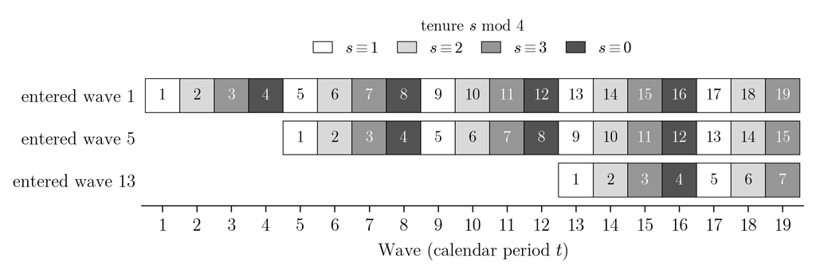

Figure 1: Observed support of the Japanese panel of Section 8: cohorts entering at waves 1, 5, and 13, observed through wave 19 (41 cells). Each cell shows the tenure $s = t - e + 1$ and is shaded by $s \bmod 4$. Because every cohort enters at a wave congruent to 1 modulo the stride $d = 4$, the shade of a cell depends only on its period, so each column has a single shade. A 4-periodic function of tenure that vanishes at $s = 1$ is therefore also a function of the period and is absorbed by $\alpha(t)$: these are the three periodic directions of Theorem 1(b), which together with the affine direction make up the four-dimensional kernel of this design (39 free parameters, rank 35).

*Antecedents.* Neither kind of direction is new to the identification literature, and we position the theorem accordingly. The affine direction is the exact translation into the measurement domain of the age–period–cohort linear dependency (Mason et al. 1973; Fosse and Winship 2019a) and of the underidentification of fully dynamic event-study specifications without never-treated units (Borusyak, Jaravel, and Spiess 2024; Sun and Abraham 2021), with tenure in the role of age or event time. The periodic directions are the measurement-domain form of the additional non-identifiability of APC models with *unequal intervals*. When age is recorded in intervals $M$ times as wide as periods, so that cohort is $c = p - Ma$, Gascoigne and Smith (2023, sec. 4.1, eqs. (4)–(5)) show that an $M$-periodic function $v_M$ can be added to the period effect and subtracted from the cohort effect without changing the linear predictor, and that the period and cohort *curvatures*—identified in the equal-interval case—are then unidentified, a phenomenon they call the curvature identifiability problem. Under the correspondence $p = t$, $Ma = e - e_0$, $c = s - 1$, and $M = d$, their $v_M$ is our $\rho$ up to sign: entry cohorts that share a stride are age groups recorded at a coarser interval than periods, and our Theorem 1(b) is their equation (4) with tenure in the role of cohort. The problem is older than that paper. Holford (2006, sec. 3) decomposes the age and period scales of an unequal-interval APC table into macro-intervals of the least common multiple and micro-intervals within them, and shows that the micro-effects carry the additional non-identifiability, which he describes as cyclical at the least common multiple and warns can be mistaken for a real cycle (Holford 2006, 984, 991); he states that the additional complexity of unequal intervals “is well known” and cites Fienberg and Mason (1979) and Holford (1983) for it (Holford 2006, 991). Those two sources support the attribution: Fienberg and Mason (1979, 37–40) show that additional linear dependencies arise when the intervals are unequal but evenly spaced, and Holford (1983, sec. 3, pp. 318–320) derives the additional aliasing for balanced integer-ratio intervals and illustrates the arbitrary saw-tooth pattern it permits (Holford 1983, sec. 3.3, pp. 321–322). Neither states the support-specific characterization or the increment-graph condition of the present theorem. Smith and Wakefield (2016, sec. 4.2, p. 598) write the same ambiguity as an explicit indicator-function transformation: for any reals $v_1, \dots, v_M$, $\delta + \alpha_i + \beta_j + \gamma_k = \delta + \alpha_i + (\beta_j + v_m \mathbf{1}\{j \equiv m \ (\mathrm{mod}\ M)\}) + (\gamma_k - v_m \mathbf{1}\{k \equiv m \ (\mathrm{mod}\ M)\})$, which is our Theorem 1(b) with $M = d$ and $v$ in the role of $\rho$, and they too attribute the phenomenon to Holford (2006). Gascoigne and Smith (2023) report a modulo-function representation in Riebler and Held (2010), which we cite on their authority alone, not having consulted that article. Borusyak, Jaravel, and Spiess (2024, sec. 3.2, fn. 15) note in passing that additional collinearity arises in event studies when treatment is staggered at periodic intervals. Two further points fix what is and is not new here. The criterion that a linear functional is estimable in a rank-deficient design exactly when it lies in the row space of the design—our annihilation of $\mathcal{K}_\tau$ in Theorem 1(a)—is classical; see Searle and Gruber (2017, sec. 5.4, “Estimable Functions”), where equation (37) states it as $q' = t'X$ and Theorem 2 gives the equivalent test $q'H = q'$ with $H = G(X'X)$ and $G$ a generalized inverse of $X'X$. Holford (2006, 985) applies that test to unequal-interval APC models, citing the first (1971) edition of the same book for it. It is the foundation we use, not a result we claim. What the present theorem adds is the support-specific characterization: which vectors are in the kernel of every staggered design (b), the increment-graph condition under which the affine-plus-periodic family exhausts the tenure projection (c) with the trapezoid follow-up rule and exact three-cohort dimension of Lemma 1, the interrupted-schedule condition of Theorem 2, and the connection to regression in Section 6, which says what the unidentified component does to fixed-effects and event-study estimators under the stated rank conditions. We make no claim to have discovered affine or periodic non-identification.

**Lemma 1 (Staggered trapezoids)** Let $\mathcal{S} = \{(e,t): e \in \mathcal{E},\ e \le t \le T\}$ with $e_1 < \dots < e_K$, $K \ge 2$, stride $d$, and write $\Delta_2 := e_2 - e_1$ for the spacing between the first two cohorts, $w := T - e_K$ for the number of periods, beyond its entry period, during which the last cohort is observed, and $\nu(\mathcal{S}) := \dim \Theta_\tau$.

15. *(Component count.)* $\nu(\mathcal{S})$ equals the number of connected components of the increment graph on $\mathcal{U} = \{1, \dots, T - e_1\}$. Hence $\nu(\mathcal{S}) \ge d$, with equality if and only if $\mathcal{S}$ satisfies C$_d$.
16. *(Sufficient condition.)* If $w \ge \Delta_2 - d$, then $\mathcal{S}$ satisfies C$_d$ and $\nu(\mathcal{S}) = d$. In particular, when the first two cohorts are $d$ apart, every $T \ge e_K$ suffices.
2. *(Three cohorts.)* If $K = 3$, then for every $T \ge e_3$,
   $$\nu(\mathcal{S}) \;=\; \max\{\, d,\; \Delta_2 - w \,\},$$
   so the condition in (i) is necessary as well as sufficient: a third cohort observed for $w$ periods removes exactly $w$ dimensions from the two-cohort indeterminacy $\Delta_2$, down to the floor $d$.
3. *(Two cohorts.)* If $K = 2$, $\nu(\mathcal{S}) = \Delta_2 = d$ for every $T \ge e_2$.
4. *(Upper bound for any number of cohorts.)* For every $K \ge 3$ and every $T \ge e_K$,
   $$\nu(\mathcal{S}) \;\le\; \max\{\, d,\; \Delta_2 - w \,\},$$
   so the three-cohort formula is an upper bound in general: extra cohorts can only shrink the identified set, and the follow-up of the *last* cohort is what the bound is stated in.

*Proof*. *(o)* Let $h \in \mathcal{K}$. The trapezoid is increment-complete, and the first cohort is observed at every $t \in [e_1, T]$, so $h_\tau$ is determined on the whole observed tenure range by $h_\tau(1) = 0$ and the first differences $\Delta h_\tau(u)$, $u \in \mathcal{U}$, and by the proof of Theorem 1(c) these differences are constant on the components of the increment graph. Conversely, let $\Delta h_\tau$ be any function on $\mathcal{U}$ that is constant on components, define $h_\tau$ by summation, and set $f(t,e) := -h_\tau(t - e + 1)$. The system $h_\alpha(t) + h_g(e) = f(t,e)$ on $\mathcal{S}$ is solvable: put $h_g(e) := f(T, e) - f(T, e_1)$ and $h_\alpha(t) := f(t, e_1)$; the residual $f(t,e) - h_\alpha(t) - h_g(e) = f(t,e) - f(t,e_1) - f(T,e) + f(T,e_1)$ is a rectangle contrast between cohorts $e$ and $e_1$ over periods $t$ and $T$, both cohorts being observed throughout $[t, T]$, so it is the telescoping sum over $t' \in [t, T-1]$ of the consecutive-period contrasts $\Delta f(t', e) - \Delta f(t', e_1) = \Delta h_\tau(t' - e_1 + 1) - \Delta h_\tau(t' - e + 1)$, each of which vanishes because $t' - e + 1$ and $t' - e_1 + 1$ are joined by an edge. Hence every assignment of one free value per component extends to an element of $\mathcal{K}$, uniquely once $h_g(e_0) = 0$ is imposed, and $\nu(\mathcal{S})$ is the number of components. Components lie inside residue classes modulo $d$, so there are at least $d$ of them when every class is represented in $\mathcal{U}$ (which holds since $\mathcal{U} \supseteq \{1, \dots, \Delta_2\}$ and $d \le \Delta_2$), with equality iff the components are the residue classes, which is C$_d$(ii).

*Seeds.* The pair $(e_1, e_k)$ contributes the edges $u \sim u + \Delta_k$, $\Delta_k := e_k - e_1$, for every $u \in [1, T - e_k]$; edges between two later cohorts $e_j < e_k$ at the same $t$ join $t - e_k + 1$ and $t - e_j + 1$, both of which are joined to $t - e_1 + 1$, so they add no components. The pair $(e_1, e_2)$ joins $u$ to $u + \Delta_2$ for all $u \le T - e_2$, i.e., whenever both lie in $\mathcal{U}$; hence every $u \in \mathcal{U}$ is in the component of its *seed* $x \in [1, \Delta_2]$, $x \equiv u \pmod{\Delta_2}$, and $\nu(\mathcal{S})$ is the number of components of the graph induced on the seeds. With $K = 2$ the seeds are pairwise disconnected and $\nu = \Delta_2 = d$: (iii). For $K \ge 3$, the pair $(e_1, e_k)$ joins the seed of $u$ to the seed of $u + \Delta_k$ for each $u \le T - e_k$; on the seed set $\mathbb{Z}_{\Delta_2} = \{1, \dots, \Delta_2\}$ this is the merge $x \sim x + \Delta_k \pmod{\Delta_2}$, available for every seed $x \le T - e_k$, hence for every $x \le w$ (since $T - e_k \ge T - e_K = w$).

*(i).* The subgroup of $\mathbb{Z}_{\Delta_2}$ generated by $\{\Delta_k \bmod \Delta_2 : k \ge 2\}$ is $d\mathbb{Z}_{\Delta_2}$, because $\gcd(\Delta_2, \dots, \Delta_K) = d$; its cosets are the residue classes modulo $d$, each of size $\Delta_2 / d$. Consider one class $C$ and the directed graph on $C$ with edges $x \to x + \Delta_k$ for every $k$ and every $x \in C$ with $x \le w$; vertices $x > w$ have no out-edges. If $w \ge \Delta_2 - d$, the interval $(w, \Delta_2]$ has length at most $d$ and therefore contains at most one element of $C$: at most one vertex of $C$ lacks out-edges. Let $A$ be a weakly connected component of this graph. If $A$ contains no vertex without out-edges, then $A$ is closed under $x \mapsto x + \Delta_k$ for every $k$, hence under addition by the subgroup they generate, hence $A = C$. So every component contains the (at most one) vertex without out-edges, and there is exactly one component: all seeds in $C$ are merged. This holds for every class, so the seeds collapse to $d$ classes, the components of the increment graph are the residue classes, C$_d$ holds, and $\nu = d$ by (o). If $\Delta_2 = d$ the condition $w \ge 0$ is vacuous.

*(ii).* With $K = 3$ the only merges are $x \sim x + \Delta_3 \pmod{\Delta_2}$ for $x \in [1, w]$: at most $w$ of them, so $\nu \ge \Delta_2 - w$, and $\nu \ge d$ always by (o). If $w \ge \Delta_2 - d$, (i) gives $\nu = d = \max\{d, \Delta_2 - w\}$. If $w < \Delta_2 - d$, the $w$ merges are independent: a cycle among them would require every source in some orbit of $x \mapsto x + \Delta_3$ on $\mathbb{Z}_{\Delta_2}$—an orbit is a full residue class modulo $d$ within $[1, \Delta_2]$, whose largest element is at least $\Delta_2 - d + 1 > w$—to lie in $[1, w]$, which is impossible. Hence $\nu = \Delta_2 - w = \max\{d, \Delta_2 - w\}$.

*(iv).* Every generator $\Delta_k$, $k \ge 3$, is available at every seed $x \le T - e_k$, hence at every seed $x \le w$, since $T - e_k \ge T - e_K = w$. Fix a residue class $C$ modulo $d$ within $\{1, \dots, \Delta_2\}$, let $A := C \cap [1, w]$ be its seeds with out-edges and $B := C \setminus A$ those without. If a connected component $P$ of the seed graph restricted to $C$ contains no vertex of $B$, then every $x \in P$ has all its out-edges, so $P$ is closed under $x \mapsto x + \Delta_k$ for every $k$, hence under the subgroup these generate—which is $d\mathbb{Z}_{\Delta_2}$, acting transitively on $C$—so $P = C$ and $B = \emptyset$. Therefore, when $B \ne \emptyset$, every component meets $B$ and distinct components meet disjoint parts of it: the number of components of $C$ is at most $|B| = |C| - |A|$, and it is $1$ when $B = \emptyset$. Summing over the $d$ classes, $\nu \le \sum_C \max\{1,\ |C| - |A_C|\}$. The classes interleave, so the $|A_C|$ differ by at most one. If some class has $B = \emptyset$ then every class has $|C| - |A_C| \le 1$, so $\Delta_2 - w \le d$ and the sum is at most $d$; otherwise every term is $|C| - |A_C|$ and the sum is exactly $\Delta_2 - w$. Either way $\nu \le \max\{d, \Delta_2 - w\}$. $\square$

Three remarks. First, (o) turns C$_d$ into a computation for any trapezoid—count the components of the increment graph—and (i) into a design rule: following the last refreshment cohort for at least $\Delta_2 - d$ periods beyond its entry is *sufficient* for C$_d$; it is necessary only in the three-cohort case, where (ii) makes the count exact. In the Japanese panel of Section 8, $\Delta_2 = 4 = d$ and (i) holds for every $T$; had the second cohort entered at wave 6 rather than 5 ($\Delta_2 = 5$, $d = 1$ with the third at 13), the last cohort would have needed $w \ge 4$ periods of follow-up before the identified set shrank to the affine line, and with $T = 16$ ($w = 3$) the identified set is two-dimensional (31 cells, 33 parameters, rank 31). The design with entries at $1, 4, 8$ and $T = 8$ discussed after Theorem 1 has $w = 0 < \Delta_2 - d = 2$ and $\nu = 3$, as (ii) gives. Second, (iv) says that the three-cohort formula bounds every design: a fourth or fifth cohort can only merge more seeds, never fewer. The bound is not tight—in the sweep reported in the replication package (all entry sets $\mathcal{E} \subset \{1, \dots, 13\}$ with $3 \le K \le 5$ and $T \le e_K + 13$; 10,934 designs) it is attained in $9{,}746$ of them and strict in $1{,}188$, while (o) holds in every case—so the component count, or the rank of $X_{\mathcal{S}}$, remains the operational check. Stating the bound in terms of the *last* cohort’s follow-up is not an artifact: with entries at $1, 5, 9, 11, 12$ and $T = 12$ the third cohort is followed for three periods and the bound computed from it would be $1$, while $\nu = 3$, because the spacing $e_3 - e_1 = 8$ is a multiple of $\Delta_2 = 4$ and merges nothing. Third, the replication package provides an R function, `design_rank()`, that builds $X_{\mathcal{S}}$ for any support (trapezoid or not), reports its rank, nullity, stride, and increment-graph components, checks the condition of (i), returns a basis of $\mathcal{K}_\tau$, and tests whether a given linear functional of $\tau$ is identified.

*Remark*. **Normalizations in practice.** Because levels of $\tau$ are never identified, every published level of panel conditioning or rotation-group bias rests on a normalization, and the practices of the literature can be read as such: the rotation-group index of the Current Population Survey, defined in the survey’s own documentation as “the ratio of the [estimate] based on a particular month-in-sample group to the average estimate from all eight month-in-sample groups combined, multiplied by 100” (quoted in Halpern-Manners and Warren 2012, fig. 1; the same index is defined and tabulated by Bailar 1975), which sets the average of the eight month-in-sample effects to a constant; Krueger, Mas, and Niu (2017)’s indexation of rotation-group bias to the full-sample mean; the reference-group restriction in the structural time-series model of van den Brakel and Krieg (2015), whose rotation-group bias varies over time and is measured relative to one group; the “average multiplicative bias by month in sample … relative to average second-stage estimates” tabulated by McIllece (2022, Table 2), which normalizes instead by the CPS second-stage estimate, a survey estimate computed from all eight rotation groups, assumed approximately unbiased and calibrated to external population controls (McIllece 2022, secs. 2.1, 3.1–3.2); and the omission of two reference categories in fully dynamic event studies (Borusyak, Jaravel, and Spiess 2024). We stress that these are analogies between *normalizations*, not equivalences between *models*: the models of van den Brakel and Krieg (2015) and McIllece (2022) are not the time-invariant additive model M4, their estimands differ from $\tau$, and a single restriction of the kind each imposes removes one dimension of $\Theta_\tau$, which is all of it only when $d = 1$. The observation that disagreements among published level estimates partly reflect differing conventions is, in our model, a corollary of Theorem 1; it is not a demonstration that those disagreements are exactly movements along $\Theta_\tau$, which would require the sources to share M4. A different route is to change the model class rather than to normalize: Feng, Hu, and Sun (2022) point-identify misclassification probabilities in a latent-state model of labor-force status with history-dependent errors by restricting response dynamics to first-order dependence, a model in which the object identified is not a mean path on tenure; we do not claim that their restrictions select a point of $\Theta_\tau$, only that the two approaches respond to the same dependency between tenure, period, and cohort.

**Corollary 1 (What is identified: curvature at the design’s stride)** On any support, a linear functional $\lambda'\tau$ is point identified if and only if $\lambda$ annihilates $\mathcal{K}_\tau$ (Theorem 1(a)). Under C$_d$ this is the pair of conditions
$$\sum_s \lambda_s\,(s-1) = 0 \qquad\text{and}\qquad \sum_{s \equiv r \ (\mathrm{mod}\ d)} \lambda_s = 0 \ \text{ for every residue } r \not\equiv 1 ,$$
and in particular the *lag-$d$ second differences*
$$\Delta_d^2\tau(s) \;:=\; \tau(s + d) - 2\,\tau(s) + \tau(s - d)$$
are identified for every $s$ with $s - d$ and $s + d$ in the support (second differences are *centered* at $s$ throughout the paper, and $\Delta^2 := \Delta_1^2$); when $d = 1$ these are the ordinary second differences, and all curvature of $\tau$ is identified. When $d > 1$, ordinary second differences $\Delta^2\tau(s)$ are *not* identified, and neither are the increments $\tau(s+d) - \tau(s)$ between refreshment tenures. The lag-$d$ second differences are the natural examples, not the whole identified space: that space has dimension equal to the number of free conditioning coordinates minus $\dim \Theta_\tau$, and contains cross-class contrasts as well. In the design of Section 8 ($d = 4$, tenures $1$ to $19$) it is $18 - 4 = 14$-dimensional; the eleven lag-4 second differences span a proper subspace, and $\Delta^2\tau(s) - \Delta^2\tau(s+4)$ for $s = 2, 3, 4$ complete a basis (Appendix A.2 uses the case $s = 2$). The displayed pair of conditions is the complete criterion under C$_d$. On a support that violates C$_d$ the identified functionals are fewer still, and must be read off $\mathcal{K}_\tau$. Zero identified curvature is consistent with an affine path (Theorem 1(b)), so identified curvature can refute nonlinear shapes of conditioning but cannot by itself establish that conditioning has stopped; see Proposition 1.

*Proof*. The first sentence is Theorem 1(a). Under C$_d$, $\mathcal{K}_\tau$ is spanned by $s - 1$ and the residue-class indicators $\mathbf{1}\{s \equiv r\}$, $r \not\equiv 1$ (Theorem 1(c)), and annihilating that basis is the displayed pair. The weights of $\Delta_d^2\tau(s)$ are $(1, -2, 1)$ at the centered positions $s-d, s, s+d$, which lie in one residue class and sum to zero there, and $\sum \lambda_s (s-1) = (s-d-1) - 2(s-1) + (s+d-1) = 0$. For $d > 1$ the weights of $\Delta^2\tau(s)$, at $s-1, s, s+1$, fall into more than one residue class—two classes when $d = 2$ (the class of $s \pm 1$, with sum $2$, and that of $s$, with sum $-2$) and three when $d \ge 3$—and at least one class other than that of tenure one has a nonzero sum; those of $\tau(s+d) - \tau(s)$ have $\sum\lambda_s(s-1) = d \ne 0$. $\square$

A stride-one design satisfying C$_1$ identifies changes in the slope of the conditioning path at unit resolution, so the stylized fact that “conditioning happens in the first few waves” has a normalization-free content there—that the curvature is concentrated in the first few waves. That conditioning *stops*, however, is not identified from curvature alone, because zero curvature is compatible with a nonzero linear trend; it requires an additional restriction such as the plateau of Proposition 1. Adjacent entry cohorts with enough follow-up are the leading case, by Lemma 1(i), but stride one is what matters, not adjacency; in a panel refreshed at a stride $d > 1$, the shape of conditioning is identified only on the coarser grid of that stride, and every published *level* is a normalization in every design. This is the sense in which a refreshment schedule is an identification decision.

## 3.1 Interrupted participation: rotation designs

M1 assumes uninterrupted participation, so that the number of interviews a unit has received coincides with its calendar tenure. Rotation designs violate it by construction. The U.S. Current Population Survey interviews a household for four consecutive months, rests it for eight, and returns it for four more—the 4–8–4 pattern whose rotation-group differences are the subject of the literature this paper began with (Bailar 1975; Solon 1986; Krueger, Mas, and Niu 2017; Halpern-Manners and Warren 2012)—so that its eighth interview arrives in its sixteenth month. The relaxation is worth making because the two clocks it separates are exactly the two sides of Theorem 1: conditioning is a function of the *dose*, the number of interviews received, while the linear dependency that makes the path unidentified is a statement about *calendar* time. When the two coincide, the dependency is unbreakable. When they do not, it is.

Let the entry cohorts be $\mathcal{E}$ with stride $d$ as before, and let every cohort follow a common *interview pattern* $J = \{\,j_1 = 0 < j_2 < \dots < j_K\,\}$ of offsets from entry: cohort $e$ is interviewed at the calendar times $e + j_k$ that lie in the field period, and the interview at $e + j_k$ is its $k$-th, so its dose is $k$. Write $j(k) := j_k$ for the elapsed calendar time at which the $k$-th interview arrives. The cell means are
$$\mu\bigl(e,\, e + j_k\bigr) \;=\; \alpha(e + j_k) \;+\; g(e) \;+\; \tau(k), \qquad \tau(1) = 0,\ g(e_0) = 0,
\tag{2}$$
which is M4 with the dose in place of the tenure; uninterrupted participation is the case $J = \{0, 1, \dots, K-1\}$, where $j(k) = k - 1$ and Equation 2 is Equation 1. We assume:

- **(P$'$) Continuous recruitment.** The entry cohorts form an arithmetic progression $\mathcal{E} = \{e_0, e_0 + d, \dots, e_0 + Ld\}$, every scheduled cell $(e, e + j_k)$ with $e \in \mathcal{E}$, $j_k \in J$ lies in the field period, the stride is itself a spacing of the pattern ($d = j' - j$ for some $j, j' \in J$), and the entry window covers the pattern’s largest within-class gap,
  $$L\,d \;\ge\; \Gamma(J, d) \;:=\; \max\bigl\{\, j' - j \;:\; j < j' \text{ consecutive in } J \cap (j + d\mathbb{Z}) \,\bigr\}.$$
  For the CPS pattern with monthly entry, $\Gamma = 12 - 3 = 9$, so (P$'$) asks for ten consecutive monthly cohorts.

An earlier version of this section stated a weaker condition—that every spacing in $d\mathbb{Z} \cap [1, j_K]$ be *realized* by some pair of cohorts observed at a common period—and claimed sharpness under it. That claim is false: with cohorts $\{1, 2, 4\}$, offsets $J = \{0, 1, 3\}$ and $T = 7$, every spacing $1, 2, 3$ is realized and the incidence graph is connected, yet the design has ten columns, rank eight, and a *two*-dimensional conditioning kernel containing $h_\tau = (0, 0, 1)$, which is not a multiple of $j = (0, 1, 3)$. The gap in the cohort set is what breaks the argument: realized spacings constrain the cohort effects only along the pairs that realize them, and with no cohort at $3$ nothing forces $h_g(4) - h_g(2)$ to equal twice $h_g(2) - h_g(1)$. (P$'$) removes the gaps. It is sufficient and not necessary; the exact criterion for any support is the projected kernel of Theorem 1(a), which the replication package computes for arbitrary patterns and cohort sets.

**Theorem 2 (Unidentified directions under a common interrupted interview schedule)** Under M2–M3, Equation 2, and a common interview pattern $J$:

1. *(Directions that are never identified.)* For every $m \in \mathbb{R}$ and every $d$-periodic $\rho$ with $\rho(0) = 0$, the vector $h_\tau(k) = m\,j(k) + \rho(j(k))$, $h_g(e) = m\,(e - e_0)$, $h_\alpha(t) = -m\,(t - e_0) - \rho(t - e_0)$ lies in the kernel of the cell design.
2. *(Sharpness under continuous recruitment.)* Under (P$'$) their tenure components exhaust the tenure projection of the kernel:
   $$\Theta_\tau \;=\; \bigl\{\, k \mapsto \tau(k) + m\,j(k) + \rho(j(k)) \;:\; m \in \mathbb{R},\ \rho \text{ $d$-periodic},\ \rho(0) = 0 \,\bigr\},$$
   whose dimension is the number of residue classes modulo $d$ represented in $J$—one when $d = 1$. Without (P$'$) the identified set can be strictly larger; its dimension is then the rank of the conditioning projection of $\ker X_{\mathcal{S}}$, computable for any support.
3. *(Identified functionals.)* Under (P$'$), $\lambda'\tau$ is identified if and only if $\sum_k \lambda_k\, j(k) = 0$ and, for $d > 1$, $\sum_{k:\, j(k) \equiv r} \lambda_k = 0$ for every residue $r \not\equiv 0$ represented in $J$. When $d = 1$, writing $T(j) := \tau(k(j))$ for the path as a function of elapsed calendar time, the identified functionals are exactly the linear combinations of second-order divided differences of $T$ on $J$—the curvature of conditioning against the *calendar*, not against the dose. For $d > 1$ the identified functionals are those with $\sum_k \lambda_k j(k) = 0$ and zero weight on every class $r \not\equiv 0$; these include the second-order divided differences taken within a residue class, but are not spanned by them—with $J = \{0,1,2,3\}$ and $d = 2$ no class has three offsets, and the one-dimensional identified space is spanned by the cross-class contrast $[T(2) - T(0)] - [T(3) - T(1)]$, a difference of within-class per-period rates.
4. *(Constant-rate paths.)* Under (P$'$), a nonzero path that is linear in the dose, $\tau(k) = c\,(k-1)$ with $c \ne 0$, belongs to the identified set of the null path—and is therefore indistinguishable from no conditioning at all—if and only if $k - 1 = m\,j(k) + \rho(j(k))$ for some such $(m, \rho)$; with $d = 1$ this says precisely that the interviews are *equally spaced*. (The zero path, $c = 0$, is the null path itself and belongs to its identified set on every schedule.) The statement concerns constant-rate paths only. Under one common schedule $k$ and $j(k)$ are in one-to-one correspondence on the observed support, so an *unrestricted* function of the interview count can always be rewritten as a function of elapsed time and conversely; what an unequally spaced design separates is a constant increment per interview from a constant increment per unit of calendar time, not the two mechanisms in general.

*Proof*. *(a)* At the cell $(e, t) = (e, e + j_k)$ we have $j(k) = t - e$, so $m\,j(k) = m(t - e_0) - m(e - e_0)$ cancels against $h_\alpha$ and $h_g$; and $\rho(j(k)) = \rho(t - e) = \rho(t - e_0)$ because $d$ divides $e - e_0$, which cancels against the second term of $h_\alpha$. The normalizations hold since $\rho(0) = 0$.

*(b)* Let $h$ be in the kernel and put $H(j) := h_\tau(k(j))$ for $j \in J$, so $H(0) = h_\tau(1) = 0$. If cohorts $e$ and $e - \delta$ are both observed at a period $t$, their offsets are $j = t - e$ and $j + \delta$, both in $J$, and subtracting the two cell equations gives
$$h_g(e) - h_g(e - \delta) \;=\; H(j + \delta) - H(j) .
\tag{3}$$
The right-hand side is a function of the offsets alone. Two facts follow, and (P$'$) supplies the cohorts and cells that each requires. *First, $h_g$ is affine on $\mathcal{E}$.* Because $d$ is a spacing of the pattern, there are $j, j + d \in J$; for every $e \in \mathcal{E}$ other than $e_0$, the cohorts $e$ and $e - d$ are both in the sample and both observed at $t = e + j$ (offsets $j$ and $j + d$), so Equation 3 gives $h_g(e) - h_g(e - d) = H(j + d) - H(j) =: G$, the same number for every $e$. Hence $h_g(e_0 + \ell d) = \ell G$, that is $h_g(e) = m(e - e_0)$ with $m := G/d$. *Second, $H$ is affine on each residue class.* Let $j < j'$ be consecutive members of $J$ in the same class modulo $d$, so that $\delta := j' - j \in d\mathbb{Z}$ and $\delta \le \Gamma(J, d) \le Ld$. Then $e_0$ and $e_0 + \delta$ are both in the sample, both observed at $t = e_0 + j'$ (offsets $j'$ and $j$), and Equation 3 with the first fact gives $H(j') - H(j) = h_g(e_0 + \delta) - h_g(e_0) = m\,\delta = m(j' - j)$. Chaining along each class, $H(j) - mj$ is constant on the class; writing $\rho$ for that constant as a function of the class—$\rho(0) = 0$ by $H(0) = 0$—gives $H(j) = mj + \rho(j)$, which is (a). The parameters are free and the representation is injective: if $mj + \rho(j) = 0$ on $J$, the pair $j, j + d \in J$ lies in one class and gives $md = 0$, so $m = 0$ and then every $\rho(r) = 0$; hence the dimension is the number of represented classes, the class of $0$ contributing $m$ and each other class its constant. On residues not represented in $J$ the periodic extension of $\rho$ is arbitrary, but such residues never occur as $t - e_0$ at an observed cell, so the kernel vector does not depend on that choice. Back-substituting, $h_\alpha(t) = -h_g(e) - H(t - e) = -m(t - e_0) - \rho(t - e_0)$ on every cell, consistently across cohorts, which fixes $h_\alpha$; the incidence graph is connected under (P$'$), so nothing else is free.

The earlier argument failed at the first fact. It read Equation 3 as defining an increment $G(\delta)$ that depends on the spacing alone and is additive in $\delta$; but Equation 3 constrains $h_g$ only along the pairs that are actually observed together, and additivity across spacings needs the intermediate cohorts to exist. In the counterexample above the pairs $(1,2)$, $(2,4)$ and $(1,4)$ realize the three spacings, but the relation $h_g(4) - h_g(1) = [h_g(4) - h_g(2)] + [h_g(2) - h_g(1)]$ is an identity, not a constraint, and nothing ties $h_g(4) - h_g(2)$ to $2[h_g(2) - h_g(1)]$.

*(c)* is Theorem 1(a) with the kernel of (b): the functional is constant on $\Theta_\tau$ iff it annihilates $j(\cdot)$ and each class indicator other than that of $0$ (the class of $0$ carries no free constant, since $\rho(0) = 0$). For $d = 1$ this is the single condition $\sum_k \lambda_k j(k) = 0$; because $\tau(1) = 0$, the weight on $k = 1$ is immaterial and can be chosen to make the weights sum to zero, after which the functionals annihilating $\{1, j\}$ on the finite set $J$ are exactly the linear combinations of second-order divided differences of $T$. For $d > 1$ the class conditions are additional and the space is as described in the statement.

*(d)* is (b) read as a membership question: $c(k-1)$ lies in the identified set of the null path iff $c(k-1) = m\,j(k) + \rho(j(k))$ for some $(m,\rho)$, and for $c \ne 0$ dividing by $c$ gives the displayed condition; for $d = 1$, $k - 1 = m\,j(k)$ for all $k$ holds iff $j(k)$ is a constant multiple of $k-1$, i.e. iff the offsets are equally spaced. $\square$

**Corollary 2 (What a 4–8–4 rotation identifies)** Take the CPS pattern $J = \{0,1,2,3,12,13,14,15\}$ with monthly entry ($d = 1$), an entry window of at least ten consecutive cohorts, and a field period covering every scheduled interview, so that (P$'$) holds ($\Gamma = 9$). Then $\Theta_\tau$ is one-dimensional, $\{\tau + m\,j(\cdot)\}$, and:

1. no level $\tau(k)$, $k \ge 2$, and no increment $\tau(k+1) - \tau(k)$ is identified;
2. every difference of *per-month* rates is identified: for any two interview intervals,
   $$\frac{\tau(k+1) - \tau(k)}{j(k+1) - j(k)} \;-\; \frac{\tau(l+1) - \tau(l)}{j(l+1) - j(l)}$$
   is a point-identified functional. In particular
   $$\mathcal{D} \;:=\; \bigl[\tau(5) - \tau(4)\bigr] \;-\; 9\,\bigl[\tau(2) - \tau(1)\bigr]$$
   is identified. It is identified *from the cohort-by-period array of cell means*, in which the cohort effects $g$ are estimated jointly with $\alpha$ and $\tau$; it is **not** in general the same weights applied to month-in-sample averages taken across periods, because those averages retain the cohort effects. If $\tau \equiv 0$ and $g(e) = a(e^2 - e_0^2)$, the contrast of month-in-sample means at any period equals $126a$ while $\mathcal{D} = 0$, and the discrepancy is constant across periods, so averaging does not remove it. Only the affine part of $g$ cancels under the weights of $\mathcal{D}$;
3. $\mathcal{D} = 0$ for every path that accumulates at a constant rate per calendar month, and $\mathcal{D} = -8c$ for a path that accumulates at a constant rate $c$ per interview. Under (P$'$), and given estimates from the joint array, the 4–8–4 design can therefore distinguish these two *constant-rate* hypotheses, which no equally spaced design can; it does not distinguish an unrestricted function of interviews from an unrestricted function of time, since on a common schedule the two are reparametrizations of each other (Theorem 2(d)).

*Proof*.

1. and (ii) are Theorem 2(c): the weights of a level or of a single increment do not annihilate $j(\cdot)$, while those of a difference of per-month rates do, since each rate contributes $\{j(k+1) - j(k)\}/\{j(k+1) - j(k)\} = 1$. For $\mathcal{D}$, $\sum_k \lambda_k j(k) = (12 - 3) - 9(1 - 0) = 0$. For the second claim of (ii), the month-in-sample-$k$ mean at period $t$ is $\alpha(t) + g(t - j_k) + \tau(k)$; applying the weights of $\mathcal{D}$ gives $\mathcal{D} + [g(t-12) - g(t-3)] - 9[g(t-1) - g(t)]$, and with $g(e) = a(e^2 - e_0^2)$ the bracketed cohort term is $a(-18t + 135) - a(-18t + 9) = 126a$, the constant $ae_0^2$ cancelling because the weights sum to zero. (iii) Substitute $\tau(k) = a + b\,j(k)$, which gives $b(12-3) - 9b(1-0) = 0$; and $\tau(k) = c(k-1)$, which gives $c(4-3) - 9c(1-0) = -8c$. $\square$

Figure 2 plots the two constant-rate paths of part (iii).

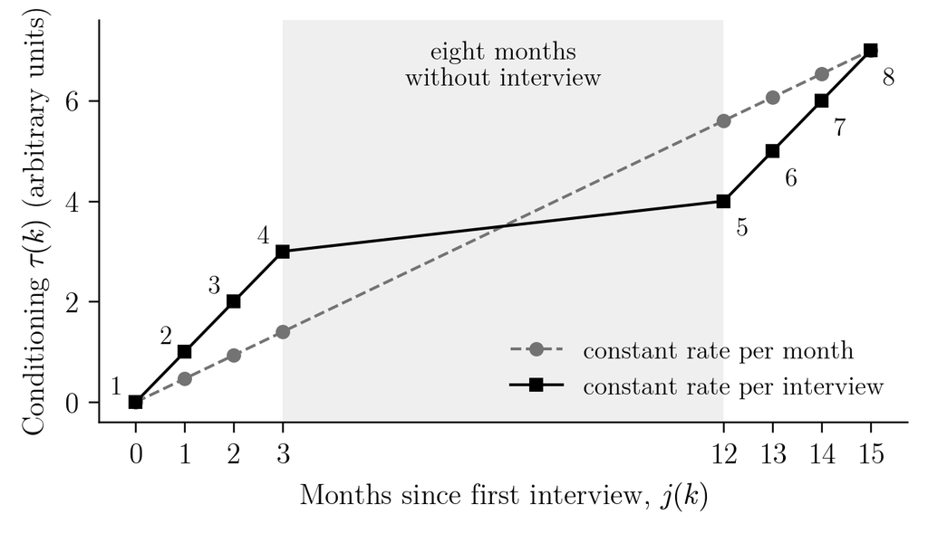

Figure 2: The two constant-rate paths of Corollary 2(iii) under the CPS 4–8–4 pattern, plotted against the months since first interview $j(k)$; labels give the interview number $k$, and the shaded band spans the eight months without an interview between the fourth and fifth interviews. A path that accumulates at a constant rate per month (dashed) is linear in $j(k)$, so it lies in the direction $m\,j(\cdot)$ that no common interview schedule identifies (Theorem 2(a)) and cannot be told apart from no conditioning. A path that accumulates at a constant rate $c$ per interview (solid) rises by the same amount at every interview, including the one after the rest; its $\mathcal{D} = -8c$ is nonzero, so under (P$'$), with the cohort effects estimated from the joint cohort-by-period array, it can be. Both paths are scaled to the same value at the eighth interview; units are arbitrary.

Three comments. First, everything downstream is unchanged: Theorem 3 is stated for an arbitrary element of $\ker X_{\mathcal{S}}$, so two-way fixed effects annihilate the unidentified component of a dose design exactly as they do that of a tenure design, and the corrected estimator of Theorem 4 is the same regression with *dose* indicators in place of tenure indicators. What changes is which component is unidentified—$m\,j(k)$ rather than $m(k-1)$—and therefore which functionals the correction can use. Second, the mechanism is the mirror image of the one in the Antecedents paragraph above: unequal spacing between *entry cohorts* creates periodic directions that no schedule can see, while unequal spacing between *a unit’s own interviews* can remove from the kernel a constant-rate path that every equally spaced schedule must live with—it does so whenever $d = 1$, and for $d > 1$ exactly when $k - 1$ is not of the form $m\,j(k) + \rho(j(k))$, which an unequally spaced pattern can still satisfy (with $J = \{0,1,3,4\}$ and $d = 3$, $k - 1 = \tfrac{2}{3} j(k) + \rho(j(k))$ with $\rho \equiv \tfrac13$ on the class of $1$). Identification in this model is entirely a question about which functions of elapsed calendar time can be written as a function of the period plus a function of the cohort. Third, (P$'$) is a real condition and not a formality: with the CPS pattern and between two and nine entry cohorts the sample cannot bridge the nine-month gap between offsets $3$ and $12$, the fourth and fifth interviews, and the identified set is two-dimensional rather than one (with a single cohort nothing separates the doses and it is seven-dimensional); and with gaps in the cohort set the identified set can be larger still, as the counterexample above shows. Both are verified by exact rank computation in the replication package, which also reproduces every row of the table below.

Table 1: Examples of what a panel’s schedule decides before any data are collected; the complete criterion is Corollary 1 for uninterrupted designs and Theorem 2(c) for interrupted ones under (P$'$), and the projected kernel of Theorem 1(a) in every case. The dimension is that of the identified set of the conditioning path. The identified functionals form a space of dimension (number of free conditioning coordinates) minus $\dim \Theta_\tau$, which for the JLPS design is $18 - 4 = 14$, of which the eleven lag-4 second differences are a proper subset; the third column lists examples, not the whole space. The last column asks whether a path accumulating at a constant rate per interview can be distinguished from no conditioning at all. Every row is verified by exact rank computation in the replication package.

| Schedule: entry stride; interview pattern | $\dim \Theta_\tau$ | Examples of identified functionals of $\tau$ | Constant-rate dose path separable from none? |
| --- | --- | --- | --- |
| adjacent entry; uninterrupted; long follow-up | 1 | all second differences $\Delta^2\tau$ | no |
| entry every $d$ waves; uninterrupted; long follow-up | $d$ | lag-$d$ second differences $\Delta_d^2\tau$ | no |
| JLPS: entries at waves 1, 5, 13; uninterrupted; $T = 19$ | 4 | $\Delta_4^2\tau$, and 3 further contrasts | no |
| entries at 1, 4, 8; uninterrupted; $T = 8$ (no follow-up) | 3 | only within increment-graph components | no |
| single refreshment at wave $e_2$; uninterrupted | $e_2 - 1$ | $\Delta_{e_2-1}^2\tau$ | no |
| monthly entry, $\ge 10$ cohorts; CPS 4–8–4 pattern | 1 | differences of per-month rates (Corollary 2) | **yes** |
| monthly entry, 2–9 cohorts; CPS 4–8–4 pattern | 2 | a strict subset of the above | no |
| cohorts 1, 2, 4; offsets 0, 1, 3; $T = 7$ | 2 | none: no nonzero functional of the two free coordinates | no |
| adjacent entry; 2 on, 2 off, 2 on | 1 | differences of per-month rates | **yes** |
| adjacent entry; every other period (1 on, 1 off) | 1 | second differences in the dose | no |
| entry every 2 periods; CPS 4–8–4 pattern | 2 | the above, plus a parity restriction | **yes** |

Table 1 summarizes the design implications. The spacing of entry cohorts, the timing of each unit’s interviews, and the length of follow-up jointly determine which functionals of conditioning a panel can ever identify: the first sets the stride and with it the minimum dimension of what cannot be known, the second decides whether a constant-rate dose path is separable from the null, and the third decides whether C$_d$ holds, so that the dimension is exactly the stride (Lemma 1(i)). None of these decisions is usually taken on identification grounds; their identification implications are cheap to compute before fielding from the scheduled support. A scheduled interruption can change which restrictions are testable, subject to the support conditions of (P$'$): a rest period that a rotation design has for cost reasons is what lets a constant per-interview increment be told apart from a constant per-month one—provided the cohort effects are estimated jointly rather than averaged away.

# 4 Attrition and Refreshment Samples: What Changes

Theorem 1 assumes M3, no attrition. Relaxing it changes the problem in a way that this paper does not solve but must locate. With nonignorable attrition, the stayers’ cell means are contaminated by selection on the latent outcome, and a refreshment sample—a fresh cross-section drawn at a later wave—identifies the population marginal that the retained sample no longer represents. The companion paper (Okubo 2026, Theorem 1) characterizes exactly what such a sample identifies about a conditioning map when attrition is unrestricted: the retention-scaled distribution of the stayers’ implied latent outcomes must be dominated, set by set, by the refreshment distribution, and every map satisfying this constraint is rationalized by an explicitly constructed admissible selection process. Three consequences of that characterization matter here. First, for observables generated by outcome-independent selection, the identified set for a location shift under *unrestricted* candidate selection mechanisms depends on the tails of the refreshment distribution, and collapses to a point whenever the refreshment density has tails thinner than exponential (Okubo 2026, Corollary 3); if independence is instead maintained for every candidate mechanism, the shift is identified by distributional alignment without any tail condition. Outcome independence of the data-generating selection alone does not imply point identification in the unrestricted class: with a Laplace refreshment density $f(y) = e^{-|y|}/2$, a true shift of zero and constant retention $p = 1/2$, the identified set is the interval $[-\log 2, \log 2]$ (Okubo 2026, Corollary 3(ii)), every shift $\varepsilon$ in it being rationalized by the outcome-dependent candidate mechanism $\pi_\varepsilon(y) = \tfrac12 f(y+\varepsilon)/f(y)$, which lies in $[0,1]$ exactly when $|\varepsilon| \le \log 2$ and preserves the reported distribution. What rules out confounding between selection and conditioning is therefore a tail condition on the refreshment distribution or a restriction on the candidate class, not the independence of the actual selection by itself. Second, under outcome-dependent attrition, the identified *set* for a location shift is governed by the distributional domination condition over the entire outcome support, including the tails; it is an interval when the refreshment distribution has a unimodal, upper semicontinuous density (Okubo 2026, Theorem 3), and it need not be connected otherwise—with a refreshment distribution placing mass $.5$ on each of two points, retention $.4$, and stayers all reporting the lower point, the feasible latent locations are the two points and nothing between them. Third, within a single cohort and with unrestricted cross-wave selection, the panel’s own longitudinal observations do not narrow that set (Okubo 2026, Theorem 2); separation is restored only by additional information—negative-control items measured once at entry, or restrictions linking selection across waves. This paper does not use any Gaussian construction of selection processes; the companion paper’s completion argument is the treatment we rely on.

# 5 Recovery: Identifying Restrictions

Each result below adds a restriction that removes part or all of $\mathcal{K}_\tau$, and each is stated together with its support conditions and with what is, and is not, testable about it. Throughout this section C$_d$ is assumed, so that $\mathcal{K}_\tau$ is the affine-plus-periodic family of Theorem 1(c); on a support violating C$_d$ the same restrictions are checked against the computed $\mathcal{K}_\tau$. Two of the three results need more than the tenure projection. Proposition 2 and Proposition 3 combine the cell means with information about the cohort effects $g$, and information about $g$ constrains $\tau$ only through the *full* kernel: they therefore assume in addition

- **(CG) Connected incidence graph.** The cohort–period incidence graph of $\mathcal{S}$ is connected—every staggered trapezoid satisfies it.

Under C$_d$ and (CG), $\mathcal{K} = \mathcal{K}_0$ exactly: every kernel vector is of the form displayed in Theorem 1(b), with $h_g(e) = m(e - e_0)$ (this is the end of the proof of Theorem 1(c), with the component constant $\kappa$ forced to zero everywhere). Without (CG) the conclusions of Proposition 2 and Proposition 3 can fail even when C$_d$ holds: on the six-cell support of Section 3 (cohorts $1, 4, 6$, each observed at entry and once more) the kernel vector $h_\tau(2) = a$, $h_\alpha(e+1) = -a$, $h_g \equiv 0$ leaves $g$ untouched, so exact knowledge of $g$—or a drift bound of $M = 0$—leaves $\tau(2)$ free. (CG) is sufficient, not necessary, for either result. The step in Proposition 2 from $h_g = 0$ to $m = 0$ needs only that some component of the incidence graph contain two cohorts: with cohorts $1, 2, 5$ on the same two-cell schedule the graph has two components, yet every kernel vector moves $g$ and knowledge of $g$ pins $\tau(2)$. The interval of Proposition 3 is guaranteed to be the identified set under (CG) and can fail to be without it, but need not: on that same three-cohort support with every cell mean zero and the zero representative, writing $a = \tau(2)$ and $b = g(5)$, the first two cohorts force $g(2) = a$ and the drift constraints read $|a| \le M$ and $|(b-a)/3| \le M$, so every $a \in [-M, M]$ is feasible (take $b = a$) and the identified set for $\tau(2)$ is exactly the displayed interval $[-M, M]$. What (CG) rules out is the mechanism of failure: without it a drift constraint between cohorts in different components is absorbed by the free component constant rather than imposed on $m$, and the implied drift between such cohorts can be moved by that constant without any compensating movement of $\hat\tau$, so the displayed interval depends on the representative and can be strictly narrower than the identified set, or empty—on the six-cell support it is $[-M, M]$ for the zero representative while $\tau(2)$ is unbounded for every $M$, and on the three-cohort support a representative with $\hat g(5) = 2.7M$ displays $[-M, 0.1M]$ while the identified set is still $[-M, M]$. We state (CG) because it is the condition every staggered trapezoid satisfies and the one under which both results hold as displayed, with the displayed interval independent of the representative. Proposition 1 uses only $\mathcal{K}_\tau$ and needs no such condition. The replication package’s `check_recovery_support.py` verifies the six-cell example, the three identified sets for $\tau(2)$ just quoted (by exact Fourier–Motzkin elimination over the kernel), and the identity $\dim\mathcal{K} = \dim\mathcal{K}_\tau + (c-1)$ of Theorem 1(d) by exact arithmetic on 9,183 supports.

**Proposition 1 (Plateau (saturation) as an identifying restriction)** Suppose $\tau(s) = \bar{\tau}$ for all $s \ge S^*$, and suppose the observed tenure range contains at least $d + 1$ consecutive tenures $s \ge S^*$. Then $\Theta_\tau$ collapses to a point: the restriction forces $m = 0$ and $\rho \equiv 0$ in Theorem 1(c), so $\tau$ is point identified on the observed tenure set. The restriction has testable *observable implications*: every identified functional $\lambda'\tau$ of Corollary 1 that is supported on tenures $s \ge S^*$ *and* has zero-sum weights, $\sum_s \lambda_s = 0$, must vanish—in particular $\Delta_d^2\tau(s) = 0$ whenever $s - d$, $s$, and $s + d$ are observed and $s - d \ge S^*$ (all three points on the plateau; equivalently $s \ge S^* + d$) and, with three or more cohorts, the constancy over time of the cohort gaps observed within the plateau window. Identified functionals whose weights do not sum to zero, such as $2\tau(5) - \tau(9)$ on a stride-four support, are not implied to vanish—on a plateau they equal $\bar\tau\sum_s\lambda_s$. The restriction itself is not testable: the affine path $\tau(s) = m(s-1)$, $m \ne 0$, satisfies every observable implication and does not saturate. A non-rejection therefore supports the plateau only against nonlinear departures; the zero-slope part of the restriction must be argued on substantive grounds or supplied by an external anchor (Proposition 2, or a refreshment design of the kind treated in the companion paper). The restriction is the measurement-domain form of the oldest identifying device in the age–period–cohort literature: Mason et al. (1973) break the linear dependency by assuming that two categories within one dimension have identical effects—“under the assumption that any two ages, periods or cohorts have identical effect parameters, differences of the form … are now estimable”—and a plateau is that assumption imposed on a block of adjacent tenures rather than on a pair.

*Proof*. On the plateau range $h_\tau(s) = m(s-1) + \rho(s)$ must be constant. The range contains some $s$ and $s + d$, and $\rho(s+d) = \rho(s)$ gives $md = 0$, so $m = 0$; then $\rho$ is constant on $d + 1$ consecutive tenures, hence on every residue class, hence everywhere, and it equals $\rho(1) = 0$. For the observable implications, an identified functional supported on the plateau takes the value $\bar\tau\sum_s\lambda_s$ there, which is zero iff the weights sum to zero. For untestability, $\tau(s) = m(s-1)$ lies in $\Theta_\tau$ of the null path and has zero identified curvature everywhere. $\square$

**Proposition 2 (Entry-wave negative controls)** Let $N$ be a set of items measuring time-invariant facts, each reported exactly once per respondent at entry ($s=1$). By construction $\tau_N \equiv 0$, so entry contrasts across cohorts identify $g_N(e) - g_N(e')$ plus sampling and selection differences. Suppose that (i) recall of the fact is stable across the calendar times at which different cohorts enter, (ii) the instrument and its administration are the same for every cohort, (iii) the entry contrasts are computed on the full entry cohorts, before any attrition (M3), or after a correction for selection of the kind the companion paper supplies, and (iv) cohort effects transport to the target item $j$ with a known or bounded loading, $g_j(e) = \Gamma_j\, g_N(e)$. Then, under C$_d$ and (CG), the negative controls identify (or bound) the cohort effects $g_j$, and knowledge of $g_j$ removes the affine direction of $\mathcal{K}_\tau$: the coefficient $m$ in Theorem 1(c) is pinned, because under (CG) every kernel vector has $h_g(e) = m(e - e_0)$, which must vanish. It does *not* remove the periodic directions, which leave $g$ unchanged. Consequently: if $d = 1$, $\tau_j$ is point identified (or bounded by the range of $\Gamma_j$); if $d > 1$, the negative controls identify $\tau_j(s)$ at the tenures $s \equiv 1 \pmod d$ and the identified functionals of Corollary 1 combined with such levels, while $\tau_j(s)$ at other tenures remains identified only up to the $d - 1$ periodic directions, whatever the loading. Point identification of the full path with $d > 1$ requires, in addition, a restriction that removes the periodic directions—the plateau of Proposition 1 spanning $d + 1$ consecutive tenures, or an external anchor of the periodic component. Conditions (i)–(iv) are assumptions about the items and the sample, not consequences of measuring the same respondents: an immutable fact does not imply a stable recall, and a common battery does not imply a common loading. We therefore recommend reporting the sensitivity of the recovered path to $\Gamma_j$ over a substantive range and, where no range can be defended, treating the battery as a diagnostic of cohort comparability rather than as an identifying instrument. Absent any restriction linking $g_j$ across cohorts, Theorem 1 applies item by item.

*Proof*. Under (i)–(iv), $g_j$ is known (or bounded) on $\mathcal{E}$. Two triples generating the same cell means differ by $h \in \mathcal{K}$, and under C$_d$ and (CG), $\mathcal{K} = \mathcal{K}_0$, so $h_g(e) = m(e - e_0)$; if both triples have the known $g_j$, then $m(e - e_0) = 0$ at some $e \ne e_0$, so $m = 0$, and the remaining freedom is $h_\tau = \rho$, $d$-periodic with $\rho(1) = 0$, which vanishes at $s \equiv 1 \pmod d$ and is identically zero iff $d = 1$. Without (CG) the first step fails, as the six-cell example above shows. On the stride-four support of Section 8, for instance, $\rho(s) = a\,\mathbf{1}\{s \equiv 2 \pmod 4\}$ with $h_\alpha(t) = -a\,\mathbf{1}\{t \equiv 2 \pmod 4\}$ and $h_g \equiv 0$ preserves every cell mean, every entry-wave negative-control contrast, and the exact value of $g$, while moving $\tau(2)$ by an arbitrary $a$. $\square$

**Proposition 3 (Partial identification under bounded cohort drift)** Suppose cohort effects drift at a bounded per-period rate: for all consecutive entry cohorts $e_k < e_{k+1}$,
$$\left| \frac{g(e_{k+1}) - g(e_k)}{e_{k+1} - e_k} \right| \;\le\; M .$$
Assume C$_d$ and (CG). The periodic directions of Theorem 1 do not move $g$, so this restriction constrains only the affine coefficient $m$. Fix any representative $(\hat\alpha, \hat g, \hat\tau) \in \Theta$ and let $\hat d_k = \{\hat g(e_{k+1}) - \hat g(e_k)\}/(e_{k+1}-e_k)$ be its implied drifts. Under (CG) the true triple has $g = \hat g + m(e - e_0)$ for some $m$ (every kernel vector is in $\mathcal{K}_0$), so $|\hat d_k + m| \le M$ for every $k$, giving $m \in [\,-M - \min_k \hat d_k,\; M - \max_k \hat d_k\,]$. Consequently, for every tenure $s \equiv 1 \pmod d$—the tenures at which the periodic component vanishes—the bounds
$$\tau(s) - \tau(1) \;\in\; \left[\, \hat\tau(s) + m_{lo}(s-1),\; \hat\tau(s) + m_{hi}(s-1) \,\right]$$
are sharp, with endpoints linear in $M$; the same holds for any identified functional of Corollary 1 combined with such a level. At tenures $s \not\equiv 1 \pmod d$ the periodic component remains free and the identified set for $\tau(s) - \tau(1)$ is unbounded for every $M$. The interval is nonempty iff $\max_k \hat d_k - \min_k \hat d_k \le 2M$, so with three or more cohorts the bound is refutable; $M = 0$ delivers point identification at the covered tenures together with an overidentification test ($\hat d_1 = \hat d_2$); $M \to \infty$ recovers $\Theta_\tau$. Reporting the breakdown value $M^*$ at which conclusions reverse is the recommended default output. In a panel refreshed at stride $d$ the covered tenures are $1, 1 + d, 1 + 2d, \dots$—in the Japanese panel of Section 8, tenures 5, 9, 13, and 17. These are tenures—arguments of $\tau$, common to every cohort, and equal to the wave number only for the original cohort—not calendar waves: that panel’s refreshment samples entered at waves 5 and 13, and the bound applies at the listed tenures because the periodic component vanishes there.

*Why first differences and not second.* The affine direction $g(e) + m(e - e_0)$ is linear in $e$, so any restriction on second differences of $g$—smoothness in the Rambachan–Roth sense—is invariant along $\Theta_\tau$ and yields no information about $m$: under $|\Delta^2 g| \le M$ the identified set for $\tau(s)-\tau(1)$ remains the whole real line for every $M$. This is the measurement-domain image of the APC fact that it is only the *slopes* of an APC model that are unidentified, so that constraints invariant to the linear component cannot recover it; the bounds must instead restrict the linear component, whether by a direct bound on a slope or, as Fosse and Winship (2019b) also show, indirectly through restrictions on the effect paths that imply one.

# 6 Where the Unidentified Component Goes: Downstream Propagation

Theorem 1 says what a panel cannot reveal about conditioning. This section asks how nonidentification of the conditioning path affects fixed-effects, difference-in-differences, and event-study estimators computed on the same panel, and finds that the answer is exactly complementary: the component of $\tau$ that cannot be identified is the component that the workhorse panel estimators discard, and the component they do not discard is identified. Identification failure upstream and robustness downstream are the same piece of linear algebra.

## 6.1 Setting

Keep the tenure structure of Section 2: individual $i$ enters at $e_i$ and is observed at calendar times $t$ with tenure $s_{it} = t - e_i + 1$. An analyst is interested in an outcome $Y^{\circ}_{it}$—the response the individual would give at tenure one, $Y^{\circ}_{it} := Y_{it}(1)$, the unconditioned response—and possibly in the effect of a regressor $D_{it}$ on it. The analyst observes the report
$$Y_{it} \;=\; Y^{\circ}_{it} \;+\; \tau(s_{it}) \;+\; \nu_{it},
\tag{4}$$
where $\tau$ is the conditioning path of Equation 1 and $\nu_{it}$ collects individual departures from the mean path. We maintain:

- **D1 (mean-additive drift).** $\mathbb{E}[\nu_{it} \mid \{D_{i't'}, s_{i't'}\}_{i',t'}] = 0$: the conditioning effect may be heterogeneous, but its mean given the design is the common path $\tau(s)$. Heterogeneity that is itself correlated with $D$ is excluded by D1; it is a separate, standard endogeneity problem and is not the subject here. Every statement below is a statement about a common additive tenure effect satisfying D1.
- **D2 (uninterrupted participation).** Units are interviewed at every wave from entry until they leave, so that calendar tenure $t - e_i + 1$ equals the number of interviews received. The baseline presentation assumes uninterrupted participation; the absorption argument of Theorem 3 extends to the dose-indexed specification of Section 3.1, with dose in place of tenure, as noted after Corollary 2, while the results that use the tenure clock explicitly (Theorem 5, Proposition 5) are stated for the uninterrupted case only.

Let $W$ be the $n \times (N + T)$ matrix of unit and calendar-time indicators for the observed rows (any unbalanced support), $M = I - W(W'W)^{-}W'$ the residual-maker that projects off unit and time effects, and for any $n$-vector $v$ write $v(s)$ for the vector with entries $v(s_{it})$. Throughout, “TWFE” means the OLS coefficient on $D$ in a regression with unit and time effects, $\hat\beta = (D'MD)^{-1} D'MY$, on whatever support is observed. The two-way *within* transformation on a balanced panel is the special case $M D = D_{it} - \bar D_{i\cdot} - \bar D_{\cdot t} + \bar D$; nothing below requires balance.

## 6.2 The absorption theorem

**Theorem 3 (Absorption of the unidentified component by two-way fixed effects)** Under D1, let $\hat\beta$ be the TWFE coefficient computed on the reports $Y$ and $\hat\beta^{\circ}$ the (infeasible) coefficient computed on the unconditioned outcomes $Y^{\circ}$, both on the same support with the same regressor. Then, conditional on the design $(D, s)$,
$$\mathbb{E}\big[\hat\beta - \hat\beta^{\circ}\big] \;=\; (D'MD)^{-1} D'M\,\tau(s) \;=\; \frac{\sum_{it} \ddot D_{it}\, \tau(s_{it})}{\sum_{it} \ddot D_{it}^2},
\qquad \ddot D := MD,
\tag{5}$$
and the following hold.

1. *Absorption.* Let $\mathcal{S}$ be the cohort–period support of the estimation sample and $Z_\tau$ the matrix of tenure indicators $\mathbf{1}\{s_{it} = s\}$. For every $h = (h_\alpha, h_g, h_\tau) \in \ker X_{\mathcal{S}}$, $M Z_\tau h_\tau = 0$. In particular $M\{a + b\,s + \rho(s)\} = 0$ for every $a, b \in \mathbb{R}$ and every $d$-periodic $\rho$, $d$ the stride of the entry cohorts in the sample. Hence the bias in Equation 5 is unchanged when $\tau$ is replaced by any other member of the identified set $\Theta_\tau$ of Theorem 1(a) computed on the same support: it is invariant along the *entire* identified set, on any support, whether or not C$_d$ holds.
2. *Exactness for unidentified drift.* If $\tau \in \mathcal{K}_\tau$—the identified set of the null path on the sample’s support; under C$_d$, an affine function of $s$ plus a $d$-periodic function—then $\mathbb{E}[\hat\beta - \hat\beta^{\circ}] = 0$.
3. *Only the identified part matters.* Writing $\tau = \tau_{\parallel} + \tau_{\perp}$ for any decomposition into a member of $\mathcal{K}_\tau$ and a remainder, the bias equals $(D'MD)^{-1}D'M\,\tau_{\perp}(s)$; in particular it is zero if and only if $\ddot D \perp \tau_{\perp}(s)$.

*Proof*. By the Frisch–Waugh–Lovell theorem, $\hat\beta = (D'MD)^{-1}D'MY$ and $\hat\beta^{\circ} = (D'MD)^{-1}D'MY^{\circ}$ on the same support, so by Equation 4, $\hat\beta - \hat\beta^{\circ} = (D'MD)^{-1}D'M\{\tau(s) + \nu\}$, and D1 removes the second term in expectation. Since $M$ is symmetric and idempotent, $D'M\tau(s) = (MD)'\tau(s) = \sum_{it}\ddot D_{it}\tau(s_{it})$. For (i), let $h \in \ker X_{\mathcal{S}}$. The cell equation $h_\alpha(t) + h_g(e) + h_\tau(t - e + 1) = 0$ holds for every fielded cell, so for every observed row, $(Z_\tau h_\tau)_{it} = h_\tau(s_{it}) = -h_\alpha(t) - h_g(e_i)$: a function of calendar time plus a function of the unit (through its entry cohort). Both lie in $\mathrm{col}(W)$, so $Z_\tau h_\tau \in \mathrm{col}(W)$ and $M Z_\tau h_\tau = 0$. The affine and periodic directions are the elements of $\mathcal{K}_0 \subseteq \ker X_{\mathcal{S}}$ of Theorem 1(b), which gives the special case; directly, $s_{it} = t + (1 - e_i)$ and $\rho(s_{it}) = \rho(t - e_0 + 1)$ when all cohorts are congruent modulo $d$. Replacing $\tau$ by another member of $\Theta_\tau$ adds $D'M Z_\tau h_\tau = 0$ to the numerator. (ii) is the case $\tau \in \mathcal{K}_\tau$. (iii) follows from (i) by linearity: $D'M\tau(s) = D'M\tau_{\parallel}(s) + D'M\tau_{\perp}(s) = D'M\tau_{\perp}(s)$, and the bias is zero iff $\ddot D'\tau_{\perp}(s) = 0$. $\square$

Three remarks. First, Theorem 3 is an exact finite-sample statement conditional on the design, not a large-$N$ approximation, and it holds on any unbalanced support: attrition, rotation, and refreshment do not disturb the argument because they change the rows of $W$, not the fact that $s_{it}$ is a sum of a unit term and a time term. Second, the theorem does not say that TWFE is immune to conditioning; it says that TWFE is immune to *every unidentified component* of the path, and that an identified component affects a particular coefficient only when it projects onto the residualized regressor $\ddot D$—so immunity to the identified part is coefficient-specific, not general. The periodic directions, which are not affine, do not bias fixed-effects estimates either: on any sample whose cohorts share a stride they are functions of calendar time, and on any sample at all every kernel direction’s tenure component is a sum of a time function and a unit function, which is the one-line content of part (i). Third, the same argument covers any estimator that partials out unit and time effects before using $D$—the two-way Mundlak, the interactive-fixed-effects estimators with unit and time effects included additively, and first differences with time effects, since $\Delta\tau(s_{it})$ is constant for affine $\tau$ and absorbed by the intercept.

**Corollary 3 (Protected and exposed designs)**

1. *Single-cohort panels.* If all units in the estimation sample share one entry cohort, then $s_{it}$ is a function of $t$ alone, $M\tau(s) = 0$ for **every** path $\tau$, and every TWFE, difference-in-differences, and first-difference coefficient computed within the cohort has zero measurement-induced bias relative to its unconditioned counterpart, under tenure drift of arbitrary shape. This is a statement about the incremental bias due to conditioning, not about the causal validity of the unconditioned estimand.
2. *Tenure-orthogonal treatment.* More generally, the bias vanishes for every $\tau$ if and only if the double-demeaned regressor sums to zero within every tenure level, $\sum_{it:\,s_{it}=s}\ddot D_{it} = 0$ for all $s$ in the support. When treatment timing is assigned independently of entry cohort given calendar time, $\mathbb{E}[D_{it}]$ is a function of $t$ alone, so $\mathbb{E}[\ddot D] = M\,\mathbb{E}[D] = 0$ and the numerator of Equation 5 has mean zero over the assignment distribution.
3. *Level contrasts.* Estimands that compare levels across units of different tenure at a common period—pooled cross-section comparisons, cohort contrasts, panel-versus-fresh-sample benchmarks, and the “experienced versus new respondent” contrasts of the conditioning literature itself—identify the *sum* $g(e) - g(e') + \tau(s) - \tau(s')$, which is invariant along $\Theta_\tau$; but its decomposition into a cohort difference and a conditioning difference is not identified, and the conditioning component $\tau(s) - \tau(s')$ that such contrasts are meant to measure inherits the non-identification of Theorem 1 unless a normalization or recovery condition of Section 5 is invoked.

*Proof*.

1. With a common $e$, $\tau(s_{it}) = \tau(t - e + 1)$ depends on $(i,t)$ only through $t$, so $\tau(s) \in \mathrm{col}(W)$ and $M\tau(s) = 0$. (b) The numerator of Equation 5 is $\sum_{it}\ddot D_{it}\tau(s_{it}) = \sum_s \tau(s)\sum_{it:\,s_{it}=s}\ddot D_{it}$, which is zero for every $\tau$ if the stated condition holds, and which is nonzero for $\tau = \mathbf{1}\{s = s_0\}$ whenever the condition fails at $s_0$. For the second claim, $\ddot D = MD$ is linear in $D$, so $\mathbb{E}[\ddot D] = M\,\mathbb{E}[D]$, and a function of $t$ alone lies in $\mathrm{col}(W)$. (c) is Equation 1 directly: a level contrast at a common $t$ between cohorts $e, e'$ with tenures $s = t - e + 1$, $s' = t - e' + 1$ equals $g(e) - g(e') + \tau(s) - \tau(s')$. Along $\mathcal{K}_0$ the conditioning component moves by $m(s - s') + \rho(s) - \rho(s')$ and the cohort component by $m(e - e')$; since $s - s' = e' - e$ and $\rho(s) = \rho(s') = \rho(t - e_0 + 1)$, the two movements cancel and the sum is unchanged, while each component moves. $\square$

Part (a) is the reassurance the applied literature has been implicitly relying on: a panel that recruited everyone at once cannot have its within-unit estimates contaminated by a common additive tenure effect satisfying D1, whatever its shape. Part (c) is the warning: the moment a design mixes tenures within a period—every rotating panel, every panel with refreshment samples, every pooled analysis of an old and a new cohort—the observed level contrast is identified but its conditioning component is not, so its reading as a conditioning effect is normalization-dependent; the TWFE protection of Theorem 3, by contrast, extends to the whole unidentified component, and what it does not cover is the identified curvature.

## 6.3 The bias is identified even though the level is not

Theorem 1 and Theorem 3 combine into a constructive statement that we regard as the practical center of the paper.

**Theorem 4 (Identified correction of two-way fixed-effects estimates)** Let $\lambda := MD\,(D'MD)^{-1}$ be the implicit weights of the TWFE estimator, so that the bias in Equation 5 is the linear functional $b(\tau) = \sum_{it}\lambda_{it}\,\tau(s_{it}) = \sum_s \Lambda_s\,\tau(s)$ with $\Lambda_s = \sum_{it:\, s_{it}=s}\lambda_{it}$. Then $\Lambda \perp \mathcal{K}_\tau$ for the kernel of the estimation sample’s own cell design—under C$_d$, the pair of conditions of Corollary 1, $\sum_s \Lambda_s (s-1) = 0$ and $\sum_{s \equiv r}\Lambda_s = 0$ for every residue class $r$ modulo the stride of the sample. Consequently $b(\tau)$ is point identified whenever $\tau$ is identified up to $\Theta_\tau$ on the estimation sample (M1–M4 on that sample, or an external estimate of the shape of $\tau$ on a design whose kernel is no larger). A feasible corrected estimator is the coefficient on $D$ in the joint regression
$$Y \;=\; W\gamma \;+\; \beta D \;+\; Z_\tau\theta \;+\; \text{error},
\tag{6}$$
where $Z_\tau$ is the matrix of tenure indicators $\mathbf{1}\{s_{it} = s\}$ and the columns of $Z_\tau$ that are collinear with $W$—exactly the directions of $\Theta_\tau$—are dropped. Suppose that, on the true outcome, $\mathbb{E}[Y^{\circ} \mid D, W, s] = W\gamma + \beta D$, and that

- **(R) Residual rank.** After partialling out $W$, the regressor $D$ is not collinear with the retained tenure indicators: $[\,MD,\; MZ_\tau\,]$ has full column rank.

Then, under D1–D2, the joint OLS coefficient $\hat\beta^{c}$ satisfies $\mathbb{E}[\hat\beta^{c}] = \beta$ exactly, conditional on the design. Equivalently, writing $\hat\theta^{c}$ for the tenure coefficients fitted *jointly* with $\hat\beta^{c}$ in Equation 6,
$$\hat\beta^{c} \;=\; \hat\beta \;-\; (D'MD)^{-1}D'M Z_\tau\,\hat\theta^{c},$$
and the right-hand side is the same for every representative $\hat\theta^{c} + h_\tau$, $h \in \ker X_{\mathcal{S}}$, of the joint fit, provided the retained tenure columns span $\mathrm{col}(Z_\tau)$ modulo $\mathrm{col}(W)$ (the display alone does not check that they do); the correction subtracts the joint-OLS estimate of $b(\tau)$, which does not depend on which representative the software reports. It is an identity for the joint fit, not for an arbitrary preliminary estimate of the path substituted into the display. No normalization of the conditioning level is required. Condition (R) fails, and $\beta$ is not identified, when treatment status is a deterministic function of tenure on the sample (for instance $D_{it} = \mathbf{1}\{s_{it} \ge s^*\}$), or more generally when $MD$ lies in the span of the retained tenure indicators. In that case the coefficient on $D$ is not determined by the data: fits with any value of $\beta$ reproduce the same fitted values. Which column a regression routine then reports as aliased depends on the order of the columns, and a routine that keeps $D$ and drops a tenure indicator reports a coefficient for $\beta$ that depends on an arbitrary normalization rather than on an identified feature of the data; (R) must therefore be checked directly, by computing the rank of $[MD, MZ_\tau]$ (or of $[W_0, D, Z_\tau]$ against $[W_0, Z_\tau]$), before the coefficient is interpreted.

*Proof*. For any $h \in \ker X_{\mathcal{S}}$, $\sum_s \Lambda_s h_\tau(s) = \lambda' Z_\tau h_\tau = (D'MD)^{-1} D'M Z_\tau h_\tau = 0$ by Theorem 3(i), so $\Lambda \perp \mathcal{K}_\tau$ and, by Theorem 1(a), $b$ is constant on $\Theta_\tau$; under C$_d$ the same follows from $\Lambda'1 = 0$, $\Lambda'(s-1) = 0$ (because $1, s \in \mathrm{col}(W)$) and $\sum_{s \equiv r}\Lambda_s = \lambda'\mathbf{1}\{s \equiv r\} = 0$ (the residue-class indicator is a function of $t$ on the sample). For the feasible estimator, the reported outcome satisfies $Y = Y^{\circ} + Z_\tau\tau + \nu$ exactly, since $\tau(s_{it}) = (Z_\tau\tau)_{it}$; hence $Y = W\gamma + \beta D + Z_\tau\tau + \{Y^{\circ} - W\gamma - \beta D\} + \nu$, and the bracketed term and $\nu$ have conditional mean zero by the outcome model and D1. Dropping the columns of $Z_\tau$ collinear with $W$ changes $\theta$ to another representative of $\Theta_\tau$ and leaves the fitted values, hence the coefficient on $D$, unchanged. Under (R) the remaining design $[W, D, Z_\tau]$ has full column rank up to $\mathrm{col}(W)$, so OLS is unbiased for $\beta$. For the equivalent form, the normal equation for $D$ in the joint fit, after partialling out $W$, is $D'M(Y - D\hat\beta^{c} - Z_\tau\hat\theta^{c}) = 0$, which rearranges to the display; adding $h_\tau$ to $\hat\theta^{c}$ changes the subtracted term by $(D'MD)^{-1}D'MZ_\tau h_\tau = 0$ by Theorem 3(i). If $MD \in \mathrm{col}(MZ_\tau)$ the coefficient on $D$ is not determined; `check_recovery_support.py` exhibits, for $D = \mathbf{1}\{s \ge 4\}$ on the staggered support of Section 8, two exact fits of the same outcome with $\beta = 0$ and $\beta = 1$. $\square$

The result inverts the usual reading of an impossibility theorem. The level of conditioning cannot be known; but the quantity the applied analyst needs—the conditioning bias in a fixed-effects coefficient—does not depend on the level, and is recoverable from the panel’s own staggered structure or from an external estimate of the conditioning *shape* (a refreshment design, or the shape library assembled in companion work). Three cautions accompany it. The correction removes the implied measurement component when the outcome model and D1 hold; its uncertainty includes the estimation of that component, and the joint regression’s variance estimator must respect the dependence in the data—we use standard errors clustered by unit—whereas a two-step procedure that first calibrates $\tau$ from the same outcome’s cell means and then subtracts it neither propagates that uncertainty nor, if the cell-mean model omits $D$, keeps the genuine effect out of the estimated tenure component. Condition (R) is a real restriction: designs in which exposure is scheduled by tenure cannot separate the effect of exposure from conditioning at all. And the correction is a *within-sample* construction: it uses the estimation sample’s own staggered structure to estimate the identified part of $\tau$, and it is not available when that structure is absent, as in the exactly aligned event studies of Section 6.4, where an *external* estimate of $\tau$ must be supplied instead. Simulation 4 (Appendix C) verifies the identity, reports the finite-sample behavior of Equation 6 under five designs including one that violates (R)—detected there by an explicit rank computation, not by which coefficient the software declines to report—and shows the practical caveat that with three entry cohorts and stride four the identified curvature rests on few degrees of freedom, so the correction is exact in expectation and imprecise in practice; the plateau restriction of Proposition 1 or an external shape estimate are the routes to precision.

## 6.4 Spurious pre-trends in tenure-aligned event studies

The protection of Theorem 3 has a precise boundary, and event studies sit on it. Let $E_i$ be the calendar time of an event for unit $i$ and $k_{it} = t - E_i$ event time. The fully dynamic event-study specification regresses the outcome on unit effects, time effects, and indicators $X_k = \mathbf{1}\{k_{it} = k\}$ for event times $k$ in a window $\mathcal{K}$, omitting a set of reference categories. It is well known (Borusyak, Jaravel, and Spiess 2024; Sun and Abraham 2021) that when every unit is eventually treated a complete set of event-time indicators is collinear with unit and time effects in two directions—a constant, and a linear trend in $k$, since $k_{it} = t - E_i$ is the sum of a time term and a unit term—so that two reference categories must be omitted (or an untreated group included) for the coefficients to be defined. The second of those directions is the same one as in Theorem 1, and it is exactly what makes tenure drift masquerade as dynamics.

**Theorem 5 (Mechanical pre-trends under exact tenure–event alignment)** Suppose the design aligns tenure with event time: $s_{it} = k_{it} + \delta$ for a constant $\delta$ on the estimation sample (equivalently $E_i = e_i + \delta - 1$: every unit’s event falls a fixed number of waves after its entry, as in rotation panels, event-recruited samples, and surveys fielded on entry schedules). Let the analyst estimate the fully dynamic specification with unit and time effects and indicators $X$ for $k \in \mathcal{K}\setminus\{k_0, k_1\}$, $k_0 \neq k_1$ two reference categories, on an estimation sample whose rows all have $k_{it} \in \mathcal{K}$, and assume that the event-time indicators are not collinear with the fixed effects: $MX$ has full column rank, where $M$ projects off unit and time effects (equivalently, $[W_0, X]$ has full column rank for any basis $W_0$ of $\mathrm{col}(W)$; the full set of unit and time indicators is itself rank-deficient by one and is not the object to check). This rank condition should be checked directly; overlap of event times and calendar periods alone does not guarantee it. For example, with event dates $E \in \{0,2,4\}$, periods $t \in \{4,\dots,7\}$, and window $k \in \{2,\dots,5\}$, every period contains several event times and every event time is observed in several periods, yet the eight columns of $[W_0, X]$ have rank seven, because all event dates are even and $k \bmod 2$ is then a function of $t$—the stride phenomenon of Theorem 1 again. Let $\ell$ be the affine function of $k$ with $\ell(k_0) = \tau(k_0 + \delta)$ and $\ell(k_1) = \tau(k_1 + \delta)$. Then, conditional on the design, the coefficients on the reports and on the unconditioned outcomes satisfy, for every $k \in \mathcal{K}\setminus\{k_0,k_1\}$,
$$\mathbb{E}\big[\hat\beta_k - \hat\beta^{\circ}_k\big] \;=\; \tau(k + \delta) \;-\; \ell(k),
\tag{7}$$
exactly. In particular, if the unconditioned outcome is such that $\mathbb{E}[\hat\beta^{\circ}_k] = 0$ for $k < 0$—an additional premise, satisfied for instance under no anticipation, parallel trends, dynamic effects that are homogeneous across event cohorts, *and* reference categories at which the effect is zero (both $k_0$ and $k_1$ before the event, say); it is not implied by no anticipation and parallel trends alone when effects are heterogeneous across cohorts (Sun and Abraham 2021, secs. 3.4–3.5), and not by homogeneity either when an omitted category carries a nonzero effect, since the affine interpolant through a nonzero post-event reference is in general nonzero at the pre-periods other than the omitted one and so induces nonzero reported pre-event coefficients (Sun and Abraham 2021, sec. 3.7, eqs. (24)–(25), p. 184); in the example in the proof below it is $-\tfrac12$ at $k = -2$ and zero at the omitted $k = -1$—then the *expected* reported pre-period coefficients equal $\tau(k+\delta) - \ell(k)$: they are nonzero in expectation whenever $\tau$ is not affine on the pre-period tenure range, with no anticipation, no selection, and no violation of parallel trends in the outcome.

*Proof*. By Equation 4 the reported outcome is $Y = Y^{\circ} + v + \nu$ with $v_{it} = \tau(s_{it}) = \tau(k_{it} + \delta)$. Decompose $\tau(k + \delta) = \ell(k) + r(k)$ with $r(k_0) = r(k_1) = 0$. The affine part satisfies $\ell(k_{it}) = \ell_0 + \ell_1(t - E_i)$, the sum of a function of $t$ and a function of $i$, hence $\ell(k) \in \mathrm{col}(W)$ and $M\ell(k) = 0$. The remainder satisfies $r(k_{it}) = \sum_{k \in \mathcal{K}\setminus\{k_0,k_1\}} r(k)\,X_{k,it}$ because $r$ vanishes at the omitted categories, so $Mv = MX\gamma$ with $\gamma = (r(k))_k$. By Frisch–Waugh–Lovell the event-time coefficients are $(X'MX)^{-1}X'MY$, and since $MX$ has full column rank, $(X'MX)^{-1}X'Mv = \gamma$ exactly; D1 removes $\nu$ in expectation. For the parenthetical premise, the same argument applied to a homogeneous effect path $\beta^{\circ}(k)$ with $\mathbb{E}[Y^{\circ}_{it}] = a_i + b_t + \beta^{\circ}(k_{it})$ gives $\mathbb{E}[\hat\beta^{\circ}_k] = \beta^{\circ}(k) - \ell^{\circ}(k)$ with $\ell^{\circ}$ the affine interpolant of $\beta^{\circ}$ at the references; this vanishes at every pre-period $k$ when $\beta^{\circ}$ is zero before the event and at both references, and it can fail when a reference carries a nonzero effect. With event dates $3, \dots, 7$, window $k \in [-2, 2]$, $\beta^{\circ}(k) = \mathbf{1}\{k \ge 0\}$ and references $k_0 = -1$, $k_1 = +1$, the design has full rank $16$ and $\mathbb{E}[\hat\beta^{\circ}_{-2}] = 0 - (-2+1)/2 = +\tfrac12$ (`check_recovery_support.py`). $\square$

The theorem has two consequences that distinguish this artifact from the failures the pre-trends literature is built to catch. Outcome-side diagnostics may detect the resulting discrepancy without identifying its measurement origin: the unconditioned outcome satisfies parallel trends by construction, so a pretest (Roth 2022) may detect the discrepancy without identifying whether it arises from measurement drift, and it need not detect it at all, since power depends on the size of $\tau(k+\delta) - \ell(k)$ relative to sampling error. Sensitivity analyses that place restrictions on violations of parallel trends (Rambachan and Roth 2023) remain applicable if the measurement-induced deviation belongs to the restriction set chosen; what Equation 7 adds is the *shape* of the deviation, $\tau(k + \delta) - \ell(k)$, which is neither linear nor smooth in general and which changes with the choice of reference categories (the term $\ell$ moves with $k_0, k_1$), so that a restriction set chosen with outcome-side violations in mind may or may not contain it. Detecting a pre-trend is not identifying its cause; removing a measurement drift does not remove other confounding. The artifact is in principle correctable from measurement-side information, because Equation 7 is a deterministic transform of the conditioning path; but under exact alignment the correction cannot be made within the sample. Each event-time indicator is then a tenure indicator, $X_k = Z_{k + \delta}$, so the joint regression of Theorem 4 with tenure indicators added cannot separate event dynamics from conditioning: the residual-rank condition (R) fails by construction, and the sample’s own cell means identify only the curvature of the *sum* of the event path and $\tau$. What is required is an *external* estimate of $\tau$ on the relevant tenure range—from a sample in which event time and tenure are not aligned, from a refreshment design of the kind treated in the companion paper, or from a shape library—whose identified part, $\tau(k+\delta) - \ell(k)$ for the analyst’s reference categories, is subtracted from the estimated coefficients. Simulation 4 reproduces Equation 7 to machine precision (Appendix C) and exhibits the rank-deficient design above; when $MX$ is rank-deficient the decomposition of the drift between time effects and event-time coefficients is not unique and Equation 7 does not apply as stated.

**Proposition 4 (Partial alignment)** If $s_{it} = k_{it} + \delta_i$ with $\delta_i$ varying across units, the drift is no longer a function of event time alone and the shift in the event-study coefficients is the linear projection
$$\mathbb{E}\big[\hat\beta - \hat\beta^{\circ}\big] \;=\; (X'M X)^{-1} X'M\,\tau(s) \;=\; (X'MX)^{-1} X'M Z_\tau\,\tau ,$$
which reduces to Equation 7 when $\delta_i \equiv \delta$. For a given path the shift is zero if and only if $X'MZ_\tau\tau = 0$, and it is zero for every path if and only if $X'MZ_\tau = 0$: the residualized event-time indicators must be orthogonal to every tenure indicator. Balance of the tenure composition of each event-time category across calendar periods does *not* suffice: with eight event dates $E = 6, \dots, 13$, two units per date with $\delta_i \in \{6, 7\}$, window $k \in [-5, 6]$ and references $k_0 = -1$, $k_1 = -2$, every event-time category has half its observations at tenure $k + 6$ and half at $k + 7$ in every period, $[W_0, X]$ has full column rank 44, and yet the path $\tau(s) = 0.3\{1 - e^{-0.6(s-1)}\}$ shifts the pre-period coefficients at $k = -5, -4, -3$ by $-0.142$, $-0.054$, and $-0.014$. When $\delta_i$ varies, the joint regression of Theorem 4 can be feasible, since $X$ and $Z_\tau$ are no longer identical, and (R) is again the condition to check.

*Proof*. Frisch–Waugh–Lovell with $Z = [W, X]$ gives the projection formula, and $\tau(s) = Z_\tau\tau$. The zero conditions read off the formula: $(X'MX)^{-1}$ is nonsingular, so the shift vanishes iff $X'MZ_\tau\tau = 0$, and for every $\tau$ iff every column of $X'MZ_\tau$ vanishes. The example is verified in Appendix C; its point is that $M$ residualizes on unit as well as time effects, so a tenure composition that is balanced within event time across *periods* is not thereby balanced after unit effects are removed. $\square$

**Proposition 5 (Measurement-side sensitivity bounds for event studies)** Assume the conditions of Theorem 5 (exact alignment, $s = k + \delta$), with adjacent reference categories $k_0$ and $k_1 = k_0 - 1$, and suppose an external source—a staggered panel with stride one, a refreshment design, or substantive knowledge—bounds the curvature of the conditioning path on the tenures the window visits:
$$\bigl|\Delta^2\tau(s)\bigr| \;\le\; C \qquad \text{for all } s \in [\,\min\mathcal{K} + \delta + 1,\ \max\mathcal{K} + \delta - 1\,].$$
Then the measurement-induced shift of every event-study coefficient obeys
$$\bigl|\,\mathbb{E}[\hat\beta_k - \hat\beta^{\circ}_k]\,\bigr| \;=\; \bigl|\tau(k+\delta) - \ell(k)\bigr| \;\le\; C\,\frac{m_k\,(m_k+1)}{2},
\qquad
m_k \;=\; \begin{cases} k - k_0, & k > k_0,\\ k_1 - k, & k < k_1,\end{cases}
\tag{8}$$
and the bound is attained when $\Delta^2\tau$ is constant at $+C$, or constant at $-C$, on the tenures between the references and $k + \delta$: the extrapolation weights on the one side of adjacent references all have the same sign, so constant curvature saturates the inequality and curvature that changes sign generally does not. Two features make this operational. The shift is invariant to the affine direction of $\Theta_\tau$: it is unchanged when $\tau$ is replaced by $\tau + a + b(s-1)$, because $\ell$ is the affine interpolant and absorbs the perturbation. Hence *no normalization of the level of conditioning is required* to apply Equation 8—only a bound on identified curvature. If the calibrating design has stride one, satisfies C$_1$, and observes the tenures $k + \delta$, $k_0 + \delta$, and $k_1 + \delta$, so that its tenure-projected kernel is the affine line (Theorem 1(c)) and the shift is a linear functional on its observed tenures, the shift is itself an identified functional of $\tau$ on that design (its weights sum to zero and annihilate $s - 1$) and Equation 8 can be replaced by a point correction; stride one alone does not suffice, as the design with entries at $1, 4, 8$ and no follow-up shows. If the calibrating design has stride $d > 1$, its periodic directions are not affine in $k$, the shift is identified only up to them, and the bound must be widened by the corresponding periodic range.

*Proof*. Write $f(x) := \tau(x + \delta)$ and $L[f]$ for the affine function through $(k_0, f(k_0))$ and $(k_1, f(k_1))$, so that the shift is $f(k) - L[f](k)$ by Equation 7. The map $f \mapsto f(k) - L[f](k)$ annihilates affine functions, hence factors through second differences. With adjacent nodes $k_1 = k_0 - 1$, write $D(x) := f(x+1) - f(x)$ for the first difference, so that the centered second difference is $\Delta^2 f(x) = D(x) - D(x-1)$. Telescoping the first differences gives, for $k > k_0$,
$$f(k) - L[f](k) \;=\; \sum_{x = k_0}^{k-1}\bigl\{D(x) - D(k_1)\bigr\} \;=\; \sum_{x=k_0}^{k-1}\ \sum_{y=k_0}^{x} \Delta^2 f(y),$$
so the weight on $\Delta^2 f(y)$ is the number of $x \in [k_0, k-1]$ with $x \ge y$, namely $k - y$ for $y = k_0, \dots, k-1$; these are $m_k, m_k - 1, \dots, 1$, all positive, and sum to $m_k(m_k+1)/2$. The case $k < k_1$ is symmetric, with weights $1, \dots, m_k$ on $\Delta^2 f(y)$ for $y = k+1, \dots, k_1$. Since the weights on either side share a sign, $|f(k) - L[f](k)| \le C \sum(\text{weights})$, with equality when $\Delta^2 f \equiv +C$ or $\equiv -C$ on the relevant range. Invariance under $f \mapsto f + a + b x$ holds because $L[a + bx] = a + bx$. $\square$

The bound quantifies the largest pre-event shift compatible with the maintained curvature restriction. In the configuration of Simulation 4—references at $k_0 = -1$, $k_1 = -2$, window $k \in [-5, 6]$—the constants $m_k(m_k+1)/2$ are $6, 3, 1$ at $k = -5, -4, -3$ and $1, 10, 28$ at $k = 0, 3, 6$, so a path whose identified curvature is bounded by $C = .06$ in outcome units can move the pre-period coefficients by at most $.36$, $.18$, and $.06$, and the post-period coefficient at $k = 6$ by at most $1.68$. The saturating path of Simulation 4 has maximal centered curvature $.061$, slightly above $.06$, for which the first bound is $.37$; its actual shifts are $.18$, $.07$, and $.02$. The bound is conservative for that path by a factor of two to three because its curvature decays geometrically away from entry rather than staying at its maximum; the factor is specific to the path, not a property of the bound. Two practical readings follow, and both concern expectations rather than realized estimates: Equation 8 bounds the conditional expected measurement-induced shift, not any single sample coefficient, and it is read under the premise of Theorem 5 that the expected unconditioned pre-event coefficient is zero. Under that premise, a confidence interval for the expected reported coefficient that excludes the entire range of admissible measurement-induced shifts, $[-C\,m_k(m_k+1)/2,\; C\,m_k(m_k+1)/2]$, is evidence against drift of the maintained magnitude as the sole explanation of a pre-trend; a point estimate outside that range is not by itself sufficient, since sampling error alone can place it there when the expected shift respects the bound, and if $C$ is itself estimated its uncertainty enters as well. Whether the comparison concerns one prespecified coefficient or a jointly assessed set should be stated in advance, the latter calling for simultaneous rather than pointwise intervals. A coefficient whose interval lies inside the range cannot be separated from measurement drift without an external estimate of the path. And because the bound grows quadratically with distance from the reference categories, distant leads and lags permit larger measurement-induced shifts under the same curvature restriction; that is a reason to report the bound alongside the coefficients when choosing the event window, not a statement that the realized artifact is largest there.

## 6.5 Which functionals survive

**Proposition 6 (Orthogonality characterization)** A linear panel functional $\theta = \sum_{it}\lambda_{it}\,\mathbb{E}[Y_{it}]$ is unbiased for its unconditioned counterpart $\theta^{\circ} = \sum_{it}\lambda_{it}\,\mathbb{E}[Y^{\circ}_{it}]$ under every drift $\tau$ in a class $\mathcal{M}$ if and only if $\sum_{it}\lambda_{it}\,\tau(s_{it}) = 0$ for all $\tau \in \mathcal{M}$. For $\mathcal{M}$ the affine paths this is the pair of moment conditions $\sum_{it}\lambda_{it} = 0$ and $\sum_{it}\lambda_{it}\,s_{it} = 0$, satisfied by every estimator that partials out unit and time effects; for $\mathcal{M}$ unrestricted it is tenure-composition balance, $\sum_{it:\,s_{it}=s}\lambda_{it} = 0$ for every $s$ in the support.

*Proof*. $\theta - \theta^{\circ} = \sum_{it}\lambda_{it}\tau(s_{it})$ by Equation 4 and D1; the “if and only if” is the definition of unbiasedness for all $\tau \in \mathcal{M}$. For affine $\mathcal{M}$ the condition is linear in $(a,b)$ and reduces to its two coefficients; for unrestricted $\mathcal{M}$ take $\tau = \mathbf{1}\{s = s_0\}$ for each $s_0$. The TWFE weights satisfy the affine pair by the proof of Theorem 3. $\square$

The second condition is the bridge to the design problem treated in companion work: a published aggregate that is balanced on time in sample is a linear functional satisfying the composition condition, so it is drift-free, and *the same functional* carries no information about the drift. This is a statement about one functional at a time—a robust aggregate estimator does not imply that the survey’s rotation-group-level data are uninformative about conditioning, only that the aggregate is; the companion paper’s balance–information theorem makes the distinction precise.

# 7 Monte Carlo Design (ADEMP)

*Aims*: noiseless verification of the identities of Theorem 1 and Corollary 1 on the JLPS-calibrated support (stride $d = 4$); size and power of the plateau observable-implications test; coverage of the drift-bound intervals of Proposition 3 at the covered tenures; dependence of level estimates on the normalization. *Data-generating mechanisms*: 19-wave staggered panel calibrated to JLPS (three cohorts, entry at $t = 1, 5, 13$); conditioning paths (null, saturating, linear-drift, non-monotone); cohort effects (null, drifting, shock at 2011 entry). *Estimands*: the centered lag-4 second difference $\Delta_4^2\tau(5) = \tau(9) - 2\tau(5) + \tau(1)$ and the identified contrast $\Delta^2\tau(2) - \Delta^2\tau(6)$; $\bar\tau - \tau(1)$ under the plateau restriction; drift bounds for $\tau(13) - \tau(1)$ and $\tau(17) - \tau(1)$ at $M \in \{0.4, 1, 2, 4\} \times$ true maximal drift. *Methods*: explicit cell-mean contrasts and regression readouts from arbitrary representatives; the plateau-constrained estimator with its observable-implications test; drift-bound intervals with the Imbens–Manski critical value. *Performance measures*: bias, MCSE, coverage of the true parameter value by the drift-bound intervals, specification-test rejection. Simulation 4 (Appendix C) verifies the identities of Section 6 (absorption, invariance, the identified correction, and the exact pre-trend formula) to machine precision and reports the finite-sample behaviour of the corrected estimator. The full protocol, with prespecified versus exploratory analyses flagged, is Appendix B (ADEMP-PreReg format); results are in Appendix A.

# 8 Illustration: A 19-Wave Panel with Two Refreshment Samples

This section illustrates the design calculus; it reports no new empirical estimates. The Japanese Life Course Panel Survey (JLPS) enrolled cohorts in 2007, 2011, and 2019—waves 1, 5, and 13—and has been observed through wave 19. Its stride is $d = 4$, its second cohort entered $\Delta_2 = 4 = d$ waves after the first, so Lemma 1(i) holds for every $T$ and C$_4$ is satisfied; its cell design has 41 cells, 39 free parameters, rank 35, and a four-dimensional kernel, exactly the affine-plus-periodic family (Figure 1). By Corollary 1 the curvature of conditioning is identified only at lag four, and the drift bounds of Proposition 3 apply at tenures 5, 9, 13, and 17, where the periodic component vanishes. Those are tenures—arguments of $\tau$, common to every cohort, and equal to the wave number only for the original cohort—not calendar waves: the refreshment samples themselves entered at waves 5 and 13. The design is thus matched to lag-four contrasts and to levels on that tenure grid, which are the objects the companion papers estimate, and poorly matched to the ordinary second differences an analyst might have expected to read off it. Two features of the design bear on Section 5. The entry negative-control set is unusually rich—23 time-invariant childhood-circumstance items asked once, at entry, of every cohort—so the affine direction can be anchored under the conditions of Proposition 2; but with $d = 4$ the battery leaves the three periodic directions untouched, and the path at tenures $s \not\equiv 1 \pmod 4$ is recovered only under the plateau restriction of Proposition 1 or an external anchor. And the 2019 entrants share no birth-cohort support with the incumbents, so that episode anchors increments rather than levels—the configuration treated fully in the companion refreshment-theory paper. The companion empirical paper implements these recovery conditions on the restricted microdata under the archive’s disclosure rules and reports the resulting battery contrasts and conditioning estimates; we do not reproduce those numbers here, and the present paper’s claims do not depend on them.

## 8.1 A descriptive illustration from published rotation-group indices

Corollary 2 says that, under (P$'$), a rotation design identifies differences of per-month rates of conditioning from the joint cohort-by-period array of cell means. Statistical agencies do not publish that array; they publish *month-in-sample indices*, each an average over many periods of the ratio of the month-in-sample-$k$ estimate to a benchmark. This subsection computes, from those indices, the transformation that Corollary 2 would apply to the array, and reports the result as what it is: a descriptive profile of the published indices, not an estimate of conditioning. The distinction is not pedantic. The month-in-sample-$k$ mean at period $t$ is $\alpha(t) + g(t - j_k) + \tau(k)$, so a contrast of month-in-sample means carries the cohort effects $g$ at eight different entry dates; the weights of $\mathcal{D}$ annihilate an affine $g$ but not a curved one, and a quadratic cohort effect $g(e) = a(e^2 - e_0^2)$ contributes $126a$ to the contrast at every period, which averaging over periods leaves intact (Corollary 2(ii)). Isolating conditioning from these indices would require estimating $g$ jointly, from cohort-by-period data, together with the sampling covariances of the published ratios, the benchmark constructions of the two sources (which differ), and a justification of the additive model on the log scale. None of that is available here, and the readings below claim none of it.

Write $b(k)$ for the published index at month in sample $k$ and $y(k) = \log b(k)$. With the CPS pattern $j = (0,1,2,3,12,13,14,15)$, the transformation of Corollary 2 produces the profile of per-month changes
$$r_k \;=\; \frac{y(k+1) - y(k)}{j(k+1) - j(k)}, \qquad k = 1, \dots, 7,$$
and the contrast $\mathcal{D}$ with the same weights as in Corollary 2. Two *restricted descriptive patterns* can be compared with the profile: a constant change per calendar month, under which all seven rates are equal and $\mathcal{D} = 0$; and a constant change per interview, under which the six within-block rates are equal and the rate across the rest period is one ninth of them. Comparison is by inspection; the published tables carry no covariances, so nothing here is a test.

Table 2: Per-month changes in the logarithms of published CPS month-in-sample indices, in log points per month, with $\mathcal{D}$ formed with the weights of Corollary 2. The profile is a descriptive transformation of published averages: it retains any non-affine cohort effect and carries no sampling covariances, and it is not an estimate of conditioning. $^{\dagger}$ In 1968–69 the CPS asked additional questions of persons not in the labor force *only* at months in sample 1 and 5 (Bailar 1975), so this row’s instrument varies with the dose and assumption M1 fails; it is shown to make the failure visible.

| Source and item | $r_1$ | $r_2$ | $r_3$ | $r_4$ (rest) | $r_5$ | $r_6$ | $r_7$ | $\mathcal{D}$ |
| --- | --- | --- | --- | --- | --- | --- | --- | --- |
| McIllece (2022, Tab. 2): unemployed, 2003–22 | $-.055$ | $-.038$ | $-.025$ | $+.001$ | $-.046$ | $-.017$ | $-.001$ | $+.510$ |
| McIllece (2022, Tab. 2): employed, 2003–22 | $.000$ | $-.001$ | $-.005$ | $+.000$ | $-.010$ | $+.001$ | $+.003$ | $+.002$ |
| Bailar (1975, Tab. 1): hours 35–40, 1968–69 | $+.052$ | $+.022$ | $+.016$ | $-.003$ | $+.032$ | $+.011$ | $+.008$ | $-.502$ |
| Bailar (1975, Tab. 1): hours 35–40, 1970–72 | $+.048$ | $+.022$ | $+.016$ | $-.003$ | $+.025$ | $+.014$ | $+.008$ | $-.457$ |
| Bailar (1975, Tab. 1): unemployed, 1968–69 $^{\dagger}$ | $-.167$ | $-.052$ | $-.038$ | $+.018$ | $-.125$ | $-.041$ | $-.017$ | $+1.671$ |

Three readings, all descriptive. First, the displayed unemployment profile is inconsistent with a constant per-month pattern: the rates range over $.057$ log points per month and $\mathcal{D} = +.51$ where that pattern gives zero. Second, it is also inconsistent with a constant per-interview pattern, which would imply equal within-block increments: within each four-month block the rate attenuates ($-.055, -.038, -.025$; $-.046, -.017, -.001$), and the second block’s first rate is nearly as steep as the first block’s. This is the “pattern … also apparent within each four-month wave” that McIllece (2022) reports; whether it reflects conditioning, cohort composition, or the benchmark construction cannot be decided from the indices. Third, the employment index varies little across months in sample: its rates are an order of magnitude smaller and $\mathcal{D} = +.002$. A small profile is not evidence that conditioning is absent, since the profile retains cohort effects of either sign; it is evidence only that the published index is nearly flat.

The last row of the table is a caution, not a finding. Because the 1968–69 CPS asked additional labor-force probes only of households in their first and fifth months in sample, the instrument varied with the dose—a direct violation of the clause of M1 that all cohorts face the same instrument at a given time—and the resulting profile shows it: the two intervals that step off or onto a probed month in sample, $1 \to 2$ and $4 \to 5$, are precisely the outliers—the steepest rate in the table and the only positive one. Solon (1986, Tab. 1) shows the same artifact after the probes were moved to months in sample 4 and 8 in 1970: in his 1974–83 averages the only two positive within-block rates are the intervals $3 \to 4$ and $7 \to 8$, which are exactly the two that end at a probed month. The framework localizes the damage; in a joint cohort-by-period analysis it would also say which contrasts avoid the affected months while annihilating $j(\cdot)$. The descriptive analogue in Solon (1986)’s averages—the rate from month three to month five against the rate from month two to month three, which differ by $14.9$ thousand persons per month—is again a transformation of published averages, not an identified contrast.

# 9 Discussion

**What the theorems change in practice.** Five practical implications follow. First, any reported *level* of panel conditioning or rotation-group bias should be read jointly with its normalization; comparisons of reported levels across studies that normalize differently reflect those normalization choices as well as any genuine difference between surveys, and cannot separate the two without the identifying restriction each study used. The discussion of normalization choices after Lemma 1 reads the major published conventions in these terms. Second, the *identified shape* of conditioning—curvature at the design’s stride, and ordinary curvature when the stride is one and C$_1$ holds—is the exportable, normalization-free quantity; meta-analyses and bias-prior libraries should accumulate identified contrasts rather than level estimates without their identifying restrictions, and should record the stride of the design that produced each one. Third, fixed-effects users can estimate Equation 6, the two-way regression with tenure indicators, rather than either ignoring conditioning or choosing a level, after checking the residual-rank condition (R) directly; event-study users on tenure-aligned designs should treat pre-period coefficients as suspect until the measurement-side check of Theorem 5 has been run. Fourth, rotation designs with continuous recruitment should analyze month-in-sample differences on the joint cohort-by-period array, with cohort effects estimated rather than averaged away, and report them as differences of per-month rates: under (P$'$) those differences are the identified functionals (Theorem 2, Corollary 2), and the rest period between interview blocks is what lets a constant per-interview increment be told apart from a constant per-month one. Published month-in-sample indices, being averages over periods, retain the cohort effects and support only descriptive comparison (Section 8.1). Fifth, before fielding or analyzing a staggered design, compute the kernel of its cell design matrix (Theorem 1(a), (d)): the refreshment schedule and the follow-up of its last cohort fix which functionals of conditioning the panel can ever deliver, a schedule with a common divisor larger than one forfeits ordinary curvature, and a cohort followed too briefly forfeits more (Lemma 1).

**Relation to companion work.** The identification theory of refreshment designs under attrition—the sharp identified set under a single refreshment, and conditions for point identification with refreshment samples at multiple tenures—is developed in companion work, where the JLPS’s two refreshment cohorts (2011, 2019) with a repeated entry-wave negative-control battery constitute, to our knowledge, the first dataset satisfying those conditions. Section 6 characterizes the propagation of *additive* tenure drift under D1–D2 and the stated rank conditions; its extension to report-dependent (state-dependent) measurement error, where the drift depends on the previous report and is not absorbed by fixed effects, is the subject of a companion paper on transition estimators. The same companion work develops the design problem: which rotation, refreshment, and mode-transition schedules make conditioning identifiable at all, and at what cost—including the result that rotation designs balanced on time in sample hold the tenure component of published aggregates constant over time at the price of the information from which it could have been estimated.

**Limits.** The model is additive throughout, in two places: cell means are additive in period, cohort, and conditioning (M4), and the individual report is the unconditioned outcome plus a common path (D1). Both are the standard assumptions of the rotation-group-bias and panel-conditioning literatures, and both are where these results end. With cohort-by-tenure or period-by-tenure interactions the indeterminacy is item-wise or cohort-wise and larger; with conditioning that depends on the previous *report* rather than on the count of interviews—state-dependent measurement error—the drift is not a function of the design alone, two-way fixed effects do not absorb it, and the companion paper on transition estimators takes it up. Nothing here is a general theory of measurement error, and the results should be read as statements about an additively separable conditioning path; Solon (1986) argued, from the rotation-group evidence itself, that the additive model of rotation-group bias is not consistent with the data for unemployment, and proposed a multiplicative alternative—on published multiplicative indices the natural reading of our model is that it applies to the logarithm of the index, which is what we do in Section 8.1. Our impossibility results concern the additive cohort-by-period cell-mean model without auxiliary identifying information; they do not bind designs that bring in validation records, paradata with exclusion restrictions, or randomized question exposure, which is precisely where the recovery conditions point. And the additive cell-mean structure, while standard, is a choice: with item-by-tenure interactions the indeterminacy is item-wise, which strengthens rather than weakens the case for shape-based reporting.

# Related literature

Our results draw on four literatures: the rotation-group-bias tradition in official statistics (Bailar 1975; Solon 1986; Krueger, Mas, and Niu 2017; McIllece 2022), where normalizations are ubiquitous—and where, by Theorem 2, the interrupted rotation pattern that tradition works with is what lets a constant per-interview increment be separated from a constant per-month one, under (P$'$) and once cohort effects are estimated jointly; the panel-conditioning literature in survey methodology (Warren and Halpern-Manners 2012; Halpern-Manners and Warren 2012; Halpern-Manners, Warren, and Torche 2017; Kraemer et al. 2024, 2025), which documents effects, and within which Das, Toepoel, and van Soest (2011) give a formal identification analysis of conditioning and attrition for a binary item in a two-wave design with a refreshment sample—the closest antecedent to our Section 4 and the companion refreshment paper; the APC identification literature (Mason et al. 1973; Fosse and Winship 2019a, 2019b), whose linear dependency we transplant to the measurement domain, and whose unequal-interval extension (Gascoigne and Smith 2023) already contains the periodic ambiguity that a common refreshment stride produces; and the modern event-study literature (Sun and Abraham 2021; Borusyak, Jaravel, and Spiess 2024), whose fully dynamic underidentification and contamination results have analogues here under M4 and D1—with tenure in the role of event time and the survey instrument in the role of the outcome equation; the closest antecedents to Theorem 5 are their treatments of excluded periods, which we use in stating its premise. Feng, Hu, and Sun (2022) point-identify CPS misclassification probabilities in a latent-state model with history-dependent errors; their object and model class differ from the additive mean model here, and we make no claim that their restrictions select a point of $\Theta_\tau$. What the two share is the dependency between tenure, period, and cohort that both must confront; the entry-wave negative controls used here check the comparability of entering groups on time-invariant facts, one component of the cross-rotation-group comparability their transport step requires, and not that condition in full. Bertoli, Jakli, and Pascoe (2026) formalize conditioning bias in two-wave event-impact surveys and propose a dual-randomization design; the present results address the many-wave staggered case under the additive cell-mean model, a different model class from theirs, in which the design choices they analyze for two waves recur at every refreshment.

# Appendix A: Simulation results

All simulations use the JLPS-calibrated support—cohorts entering $t = 1, 5, 13$, $T = 19$, stride $d = 4$—so that the identified set of Theorem 1 is four-dimensional and ordinary second differences are not identified. The specifications below correspond to the accompanying code; every number quoted in this appendix is read from a named column of the corresponding output file, and the replication package’s `check_manuscript_values.R` reproduces each of them from those files.

## Simulation 1: noiseless identities, normalizations, and the plateau test

Design: $B = 500$; cell noise $1/\sqrt{1000}$ (one thousand respondents per cell with unit outcome variance); scenarios S1 null / S2 saturating, $\tau(s) = 0.2\{1 - e^{-0.6(s-1)}\}$ / S3 = S2 + linear drift $0.01(s-1)$ / S4 = S2 + late nonlinear drift $0.004\max(s-6,0)^2$; cohort shock G1 ($+0.15$) on the 2011 cohort; plateau window $s \ge 6$.

*Noiseless identity tests.* On population cell means, adding the periodic null direction $\rho = (0, 0.30, -0.10, 0.20)$ (period four, $\rho(1) = 0$) to $\tau$ and subtracting $\rho(t)$ from $\alpha$ changes no cell mean ($5.6 \times 10^{-17}$). The ordinary second difference $\Delta^2\tau(3)$ moves from $-0.022$ to $+0.678$; the centered lag-4 second difference $\Delta_4^2\tau(5) = \tau(9) - 2\tau(5) + \tau(1)$ does not move; and the explicit cell-mean contrast $[\mu(1,9) - \mu(5,9)] - [\mu(1,5) - \mu(5,5)]$—first argument the entry date, as in Equation 1; the cohorts entering at $t = 1$ and $t = 5$ compared at $t = 9$ and at $t = 5$—returns $\Delta_4^2\tau(5) = \tau(9) - 2\tau(5) + \tau(1) = -0.1654$ to $10^{-17}$ before and after the perturbation. (The same two cohorts compared at $t = 13$ and $t = 9$ would return $\Delta_4^2\tau(9) = \tau(13) - 2\tau(9) + \tau(5) = -0.0150$, a different identified functional.) This is Theorem 1 and Corollary 1 at machine precision. Earlier versions labeled these two contrasts by their first tenure, $\Delta_4^2\tau(1)$ and $\Delta_4^2\tau(5)$; the quantities are unchanged, and the labels now follow the centered convention of Corollary 1.

| Scenario | bias level N1 | bias level N2 | $\Delta_4^2\tau(5)$ true | bias (contrast) | MC sd | bias $\bar\tau$ (plateau) | rejection |
| --- | --- | --- | --- | --- | --- | --- | --- |
| S1 null | 0.000 | 0.000 | 0.000 | 0.001 | .064 | 0.001 | .058 |
| S2 saturating | −0.051 | −0.102 | −0.165 | 0.004 | .061 | −0.006 | .048 |
| S3 + linear drift | −0.089 | −0.140 | −0.165 | 0.001 | .065 | −0.097 | .054 |
| S4 + nonlinear | −0.173 | −0.124 | −0.129 | 0.005 | .060 | −0.408 | 1.000 |

Rows are the G0 (no cohort shock) setting; the G1 rows of `sim1_results.csv` differ from them only within Monte Carlo error. Three theorem-consistent facts: (i) level estimates differ by normalization; (ii) the estimated bias of the identified lag-4 contrast is small relative to its Monte Carlo uncertainty in every scenario (Monte Carlo standard error $.003$); (iii) the plateau *observable-implications* test (constancy over time of the cohort gaps within the window) has rejection rates near the nominal $.05$ in S1 (null), S2 (saturating path) and S3 (S2 plus the pure linear drift that Proposition 1 declares undetectable)—$.058$, $.048$ and $.054$ over $500$ replications—and rejects in every replication under the nonlinear violation S4 (499 of 500 in the G1 setting), while the plateau-constrained estimator absorbs the drift it cannot see (bias $-0.097$ under S3, which adds a linear drift to the saturating path of S2). [sims/sim1_normalizations.R; sim1_results.csv]

## Simulation 2: identified and unidentified curvature readouts

The target is $\theta := \Delta^2\tau(2) - \Delta^2\tau(6)$, an identified functional on this support—its weights sum to zero within every residue class modulo four and are orthogonal to $s - 1$—contrasted with $\Delta^2\tau(3)$, which is not identified (Corollary 1). For noiseless cell means a saturated regression returns a representative of $\Theta_\tau$: unidentified functionals of it depend on which representative the software chose, whereas identified functionals equal their true values.

*Noiseless identities.* $\theta = -0.03702$; the correctly centred contrast $-\Delta^2 D(6)$, $D(t) = \mu(1,t) - \mu(5,t)$ (first argument the entry date: the cohorts entering at $t = 1$ and $t = 5$), returns it to $10^{-16}$; the regression readout $\Delta^2\hat\tau(2) - \Delta^2\hat\tau(6)$ from an arbitrary representative returns it to $10^{-15}$; the regression readout of $\Delta^2\hat\tau(3)$ is $-0.072$ against a true $-0.022$, and moves with the representative.

| Scenario | $\theta$ true | bias (contrast) | MC sd | bias (regression readout) | MC sd | $\Delta^2\tau(3)$ true | mean readout |
| --- | --- | --- | --- | --- | --- | --- | --- |
| S2 | −0.037 | 0.006 | .110 | 0.000 | .080 | −0.022 | −0.075 |
| S3 | −0.037 | 0.003 | .107 | 0.003 | .081 | −0.022 | −0.072 |

The Monte Carlo estimates of both estimators are consistent with unbiasedness for this identified functional (Monte Carlo standard error $.005$); the regression readout is the more efficient because it uses every cell. The recommendation: read identified functionals off any representative, but check identification first. [sims/sim2_direct_contrast.R; sim2_results.csv]

## Simulation 3: drift-bound intervals (Proposition 3)

Design: same support; saturating $\tau(s) = 0.25\{1 - e^{-(s-1)/2}\}$; cohort effects $g = (0, 0.10, 0.22)$, per-period drifts $(0.025, 0.015)$, so the true maximal drift is $M_0 = 0.025$; $n = 500$ per cell, $B = 300$, endpoint standard errors by parametric bootstrap ($150$ draws). The interval is $[\hat\tau_{lo} - c\,\hat\sigma_{lo},\ \hat\tau_{hi} + c\,\hat\sigma_{hi}]$ with a critical value $c$ in the form of Imbens and Manski (2004), solving $\Phi(c + \hat\Delta/\hat\sigma) - \Phi(-c) = 0.95$, where $\hat\Delta$ is the estimated width of the identified set *truncated at zero* and $\hat\sigma$ the larger endpoint standard error (a standard error, unlike the asymptotic standard deviation that plays this role in Imbens and Manski (2004)), so that $c \to 1.645$ for a wide set and $c \to 1.96$ for a point; the endpoints themselves are the raw estimates and may cross, in which case the estimated set is empty and the rate is recorded. The target is coverage of the true parameter value, not of the whole set. The bounds are evaluated at $s = 13$ and $s = 17$, the tenures congruent to 1 modulo 4 at which Proposition 3 applies. Two further designs probe the narrow-set case. G3 sets the true drifts to $(+0.025, -0.025)$: at $M = M_0$ both constraints bind and the identified set for $m$ is a point, but its two endpoints are extrema over *distinct* drifts, so each endpoint estimator is a smooth function of the cell means—the population endpoints coincide without any tie inside an extremum. G4 sets the true drifts to $(+0.025, +0.025)$: both extrema are tied, the upper endpoint $M - \max_k \hat d_k$ subtracts the maximum of two equal quantities and is not smooth, and at $M = M_0$ the identified set for $m$ is an interval of width $2M_0 - (\max_k d_k - \min_k d_k) = 2M_0 = .050$, with the truth at its upper endpoint; the corresponding population widths for $\tau(13)$ and $\tau(17)$ are $12 \times .050 = .600$ and $16 \times .050 = .800$ (`check_recovery_support.py` and `check_manuscript_values.R` assert these).

At the population level the representative’s implied drifts under G2 are $(0.0117, 0.0017)$, each displaced from the truth by the same constant—the linear part the representative reassigns to the cohort dimension—while their difference is preserved; on the subgrid $s \in \{1, 5, 9, 13, 17\}$ the representative agrees with the truth up to that linear part to $10^{-16}$. At $M = M_0$ the sharp interval for $\tau(13)$ is $[-0.23, 0.25]$ and contains the truth $0.249$ at its upper endpoint (the true drift equals $M_0$); at $M = 0.4M_0$ it is $[-0.05, 0.07]$ and excludes it.

| DGP | $M / M_0$ | coverage, $\tau(13)$ (IM / fixed $z$) | median width | median set width | median $c$ | coverage, $\tau(17)$ (IM / fixed $z$) | median width | empty rate |
| --- | --- | --- | --- | --- | --- | --- | --- | --- |
| G2 | 0.4 (violated) | .127 / .123 | 0.33 | 0.12 | 1.65 | .107 / .107 | 0.43 | .05–.07 |
| G2 | 1.0 | **.957** / .957 | 0.69 | 0.48 | 1.64 | **.957** / .957 | 0.91 | 0 |
| G2 | 2.0 | 1.000 / 1.000 | 1.29 | 1.08 | 1.64 | 1.000 / 1.000 | 1.71 | 0 |
| G2 | 4.0 | 1.000 / 1.000 | 2.49 | 2.28 | 1.64 | 1.000 / 1.000 | 3.31 | 0 |
| G3 (coincident endpoints) | 0.4 (violated) | .020 / .007 | — | $-0.36$ | 1.96 | .023 / .007 | — | 1.00 |
| G3 (coincident endpoints) | 1.0 | **.953** / .900 | 0.25 | 0.00 | 1.93 | **.940** / .910 | 0.33 | .47–.50 |
| G3 (coincident endpoints) | 2.0 | 1.000 / 1.000 | 0.82 | 0.60 | 1.64 | 1.000 / 1.000 | 1.08 | 0 |
| G3 (coincident endpoints) | 4.0 | 1.000 / 1.000 | 2.02 | 1.80 | 1.64 | 1.000 / 1.000 | 2.68 | 0 |
| G4 (tied constraint) | 0.4 (violated) | .017 / .017 | 0.38 | 0.19 | 1.64 | .013 / .013 | 0.51 | 0 |
| G4 (tied constraint) | 1.0 | **.880** / .880 | 0.74 | 0.55 | 1.64 | **.890** / .890 | 0.99 | 0 |
| G4 (tied constraint) | 2.0 | 1.000 / 1.000 | 1.34 | 1.15 | 1.64 | 1.000 / 1.000 | 1.79 | 0 |
| G4 (tied constraint) | 4.0 | 1.000 / 1.000 | 2.54 | 2.35 | 1.64 | 1.000 / 1.000 | 3.39 | 0 |

Three readings, all of a finite-sample experiment with $300$ replications; the Monte Carlo standard error of a coverage figure is $\sqrt{p(1-p)/300}$, about $.013$ near $.95$ and about $.019$ and $.018$ at the G4 figures of $.880$ and $.890$. First, at the true $M$ on the designs without a tie, estimated coverage of the true value is close to 95% (G2: $.957$; G3: $.953$ and $.940$ with the adaptive critical value against $.900$ and $.910$ with the fixed $1.645$); above the true $M$ the interval is conservative, and under a violated bound coverage collapses, as it should. On G2 the set is wide relative to the endpoint standard errors, $c = 1.645$, and the two intervals coincide. On G3 the estimated set is empty in half the replications, since sampling error puts the two coincident endpoints in the wrong order with probability one half, and the adaptive critical value rises toward $1.96$; the five-point difference between the two intervals is the observed difference on this design, not a demonstration of a theorem. Second, on G4—the design with a genuine tie—the interval **undercovers**: $.880$ and $.890$ at $M = M_0$, with the adaptive and fixed critical values agreeing because the estimated set is wide. The mechanism is the non-smoothness the tie creates: the sample maximum of two drifts with equal population values is biased upward, so the estimated upper endpoint $M - \max_e \hat d_e$ is biased downward, and a bootstrap standard deviation of that endpoint does not correct a bias; the truth sits at the upper end of the population set and is missed about one time in nine. Third, none of this is a validity result. The uniform coverage of Imbens and Manski (2004, Lemma 4, p. 1850) holds under their Assumption 1, whose part (iii) reads: for all $\epsilon > 0$ there are $\nu > 0$, $K$, and $N_0$ such that $N \ge N_0$ implies $\Pr(\sqrt N\,|\hat\Delta - \Delta| > K\Delta^{\nu}) < \epsilon$, uniformly over the model class. At a point-identified parameter, $\Delta = 0$, this requires $\Pr(\hat\Delta \neq 0) \to 0$. Our raw width $(s-1)(2M - |\hat d_1 - \hat d_2|)$ is continuously distributed at every finite $n$, and its truncation at zero is nonzero with probability tending to one half, so the condition fails and Lemma 4 does not apply to the interval as implemented uniformly over a model class that includes the point-identification boundary represented by G3. That is a failure of a sufficient condition over that class, not a proof of undercoverage, and not a statement about a class bounded away from zero width and from tied constraints, where a different validity argument remains possible; G4’s tie additionally strains the joint asymptotic-normality premise of the endpoint estimators. (Our $\hat\sigma$ is an endpoint standard error, so the ratio $\hat\Delta/\hat\sigma$ used in the critical-value equation is their $\sqrt N \hat\Delta / \max(\hat\sigma_l, \hat\sigma_u)$ of equation (7), in which $\hat\sigma$ denotes an asymptotic standard deviation; no factor is missing.) What the experiment supports is narrower: the sharp population bounds of Proposition 3 are exact; the adaptive critical value improves on the fixed one on the coincident-endpoint design; and where a constraint is tied the endpoint estimator’s bias, not its variance, is the problem, which a procedure that resamples the constraint set or corrects the extremum’s bias would need to address. Two practical lessons attach. The intervals are wide at late tenure: the interval for $m$ enters $\tau(s)$ multiplied by $(s-1)$, so at $s = 17$ even the correctly specified bound spans nearly a standard deviation; the level of long-run conditioning is expensive, and only some curvature contrasts are estimable, under the support conditions of Corollary 1. And with three cohorts the emptiness test has little power against modest violations: refutation of a drift bound needs more refreshment cohorts or an external anchor. [sims/sim3_drift_bounds.R; sim3_results.csv]

# Appendix B: Simulation protocol (ADEMP-PreReg format)

This appendix states the simulation protocol in the ADEMP structure, with the prespecification status of every analysis flagged: **[P]** = prespecified before any simulation was run; **[E→C]** = discovered in an exploratory run, then confirmed in a fresh simulation; **[A]** = added or corrected after the protocol was first fixed, and therefore not prespecified.

**Aims.** (A1) **[P]** Verify numerically that level estimates of $\tau$ depend on the normalization while identified curvature does not (Theorem 1, Corollary 1). (A1$'$) **[A]** Noiseless identity tests of the periodic null direction. (A2) **[P]** Size and power of the plateau observable-implications test (Proposition 1), including its predicted blindness to pure linear drift. (A3) **[P]** Bias of the plateau-constrained estimator under correct and violated saturation. (A4) **[P]** Coverage of the drift-bound intervals (Proposition 3) at correctly specified, conservative, and violated $M$, at the covered tenures. (A5) **[A]** Compare readouts of identified and unidentified functionals from saturated regressions with explicit contrasts. (A6) **[A]** Coverage of the Imbens–Manski interval against a fixed-$z$ interval on a design in which the identified set is a point. (A7) **[A]** Coverage on a design in which the binding constraint is tied.

**Data-generating mechanisms.** JLPS-calibrated support: cohorts entering $t = 1, 5, 13$, $T = 19$. Sims 1–2: cell noise $1/\sqrt{1000}$; paths S1 null, S2 $\tau(s) = 0.2\{1 - e^{-0.6(s-1)}\}$, S3 = S2 + $0.01(s-1)$, S4 = S2 + $0.004\max(s-6,0)^2$; cohort effects G0 null, G1 shock $+0.15$ on the 2011 cohort. Sim 3: outcome sd $1$, $n = 500$ per cell; S2$'$: $\tau(s) = 0.25\{1 - e^{-(s-1)/2}\}$; G2 drifting $g = (0, 0.10, 0.22)$, drifts $(+M_0, +0.6M_0)$ with $M_0 = 0.025$; G3 *coincident endpoints*, $g = (0, 0.10, -0.10)$, drifts $(+M_0, -M_0)$, so that at $M = M_0$ the set for $m$ is a point whose two endpoints are extrema over distinct drifts; G4 *tied constraint*, $g = (0, 0.10, 0.30)$, drifts $(+M_0, +M_0)$, so that the maximum over drifts is a tie and the set for $m$ at $M = M_0$ has width $2M_0$. Factorial: sim 1 crosses S1–S4 × {G0, G1}; sim 2 runs S2, S3 × G1; sim 3 runs S2$'$ × {G2, G3, G4}. $B = 500$ (sims 1–2), $B = 300$ with $150$ bootstrap draws (sim 3).

**Estimands.** $\Delta_4^2\tau(5) = \tau(9) - 2\tau(5) + \tau(1)$ and $\theta = \Delta^2\tau(2) - \Delta^2\tau(6)$ (identified); $\Delta^2\tau(3)$ (not identified; reported to exhibit its arbitrariness); $\bar\tau - \tau(1)$ under the plateau restriction with window $s \ge 6$; $\tau(13) - \tau(1)$ and $\tau(17) - \tau(1)$ for the drift bounds; the observable-implications and emptiness test statistics.

**Methods.** Saturated cell-mean OLS under normalization N1 (reference level) and N2 (zero mean along the affine direction); explicit cell-mean contrasts; the plateau-constrained estimator with the cohort-gap-constancy test; the representative-plus-drift-interval construction of Proposition 3 with the linear part read on the subgrid $s \equiv 1 \pmod 4$, parametric-bootstrap endpoint SEs, and the interval $[\hat\tau_{lo} - c\hat\sigma_{lo}, \hat\tau_{hi} + c\hat\sigma_{hi}]$ with a critical value $c$ in the form of Imbens and Manski (2004) (coverage of the true parameter value; $c$ between $1.645$ and $1.96$ according to the estimated width, truncated at zero, relative to the endpoint standard error; raw endpoints, which may cross), with the fixed-$z$ ($1.645$) interval reported alongside. The adaptive critical value is used as a finite-sample device; no uniform-validity claim is made for it, since the interval does not satisfy Assumption 1(iii) of the cited article at a point-identified parameter.

**Performance measures.** Bias and Monte Carlo SE of each estimand; exact invariance of identified functionals under null-direction perturbations (predicted identity, not approximation); rejection rates of the observable-implications test at nominal .05; coverage of the true $\tau(s)$ by the Imbens–Manski interval and by the fixed-$z$ interval, median interval width, median estimated set width, and median critical value at each $M/M_0 \in \{0.4, 1, 2, 4\}$; emptiness rate.

**Deviations from protocol.** Recorded here in full. (1) Proposition 3 was restated in terms of first-difference drift, which the affine direction moves, before sim 3 was run; an earlier draft had bounded second differences, which it does not. (2) Sims 1–2 were rewritten with noiseless identity tests after the periodic null direction was recognized; an earlier reading of the same discrepancy as “boundary-dummy contamination” of saturated regressions was a misreading of the non-identification of ordinary second differences on a stride-four support and is withdrawn. (3) Sim 2’s contrast estimator is centred so that its estimand is $\theta$ above. (4) Sim 3 replaced a fixed critical value of $1.645$ by the Imbens–Manski critical value and added the design G3, on which the fixed value gives $90\%$ coverage. G3’s endpoints coincide without a tie inside an extremum; the tied-constraint design G4 was added, on which the interval undercovers ($.88$–$.89$), and the uniform-validity language was withdrawn. (5) Sim 4’s attrition mechanism was made monotone, consistent with D2; the design of the exactly aligned event study is unchanged. (6) Sim 1’s cell-mean contrast for $\tau(9) - 2\tau(5) + \tau(1)$ compares the two cohorts at $t = 9$ and $t = 5$, as the code always did; the appendix prose had named the wrong periods. (7) The lag-4 second differences are now labeled by their center ($\Delta_4^2\tau(5)$, $\Delta_4^2\tau(9)$) rather than by their first tenure, the G4 population width is stated correctly as $2M_0$, the coverage target is named as coverage of the true parameter value, and `check_manuscript_values.R` was rewritten to fail on missing, duplicated, or non-finite rows and to use a scale-aware tolerance for floating-point identities; no random draw changed. All scripts and seed-controlled outputs accompany the replication package, and `check_manuscript_values.R` asserts every number quoted in Appendices A and C against named output columns.

# Appendix C: Simulation 4 — downstream propagation

*Design.* Staggered panel with cohorts entering $t = 1, 5, 13$ (stride $d = 4$), $T = 19$, $n = 200$ per cohort, unit and time effects, monotone attrition with an exit hazard increasing in tenure (a unit that leaves does not return, so that D2 holds and the support is an unbalanced trapezoid), and a staggered binary regressor $D$ adopted at a random calendar time after entry (30% never adopt) with true coefficient $0.5$. Reports add a conditioning path to the unconditioned outcome: S (saturating, $\tau(s) = 0.30\{1 - e^{-0.6(s-1)}\}$), L (affine, $0.05(s-1)$), or S+L. For the pre-trend block, eight consecutive cohorts ($e = 1, \dots, 8$, $T = 20$, $n = 60$, no attrition) each experience an event five waves after entry ($\delta = 6$), the estimation window is $k \in [-5, 6]$, and the unconditioned outcome has no event effect and no anticipation; the fully dynamic specification omits $k_0 = -1$ and $k_1 = -2$. Seed 20260916; code `sims/sim4_downstream.R` (v3); every number below is written by the script to `sim4_manuscript_values.csv` under a named quantity. The cell-mean design of the main support has 41 cells, 39 free parameters, rank 35, and nullity 4, as Theorem 1(d) requires for $d = 4$ under C$_4$ on a connected support.

*Deterministic identities.* Conditional on one realization of the design, Theorem 3 holds exactly: the observed bias of the TWFE coefficient equals $(D'MD)^{-1}D'M\tau(s)$ to $2 \times 10^{-14}$ (S and S+L: bias $0.0256$; L: bias $9 \times 10^{-15}$). Adding the affine direction $0.7 + 0.2(s-1)$ changes the estimate by $4 \times 10^{-14}$, and adding the *periodic* direction $\rho = (0, 0.30, -0.10, 0.20)$ of period four changes it by $9 \times 10^{-15}$: the bias is invariant along the entire four-dimensional identified set, as Theorem 3(i) states. In a single-cohort panel the bias is $10^{-16}$ for the saturating path (Corollary 3(a)). Under exact alignment, all ten event-study coefficients shift by $\tau(k+\delta) - \ell(k)$ to $1.5 \times 10^{-14}$ (Theorem 5). The residuals just quoted are those of the archived run, whose environment the release record documents; they are machine-precision quantities that vary with the platform’s linear algebra, and the checker asserts each identity at the scale-aware tolerance $10^{-10}$, some five orders of magnitude below the displayed precision of any estimate, rather than requiring the archived residuals to recur. The measurement-induced *shifts* in the three pre-period coefficients are $-0.183$, $-0.070$, and $-0.018$ at $k = -5, -4, -3$; these are not the estimated coefficients themselves, which in this realization are $+0.068$, $+0.061$, and $+0.014$ on the reports and $+0.252$, $+0.131$, and $+0.032$ on the unconditioned outcome—the latter being sampling error of a regression with 480 units and no event effect, and the former that error plus the shift. On the same aligned design the residualized event-time and tenure indicators are collinear, $\mathrm{rank}[MX, MZ_\tau] = 10$ against $21$ columns, so condition (R) fails and no within-sample correction exists. The rank-deficient design of Section 6.4 (event dates $\{0,2,4\}$, periods $4$–$7$, window $2$–$5$, two references omitted) has eight columns and rank seven. The partial-alignment design of Proposition 4 (event dates $6, \dots, 13$, two units per date with $\delta_i \in \{6,7\}$) has a tenure composition of exactly one half at each of $k + 6$ and $k + 7$ in every $(k,t)$ cell, $\mathrm{rank}[W_0, X] = 44$ of $44$, $\max|X'MZ_\tau| = 6.0$, and shifts of $-0.1419$, $-0.0544$, $-0.0142$ at $k = -5, -4, -3$ for the saturating path.

*Identified correction.* On the main design, the joint regression Equation 6 (four tenure indicators aliased with the fixed effects and dropped) returns $0.578$ against the infeasible unconditioned estimate $0.568$ and the reported-outcome estimate $0.594$, with unit-clustered standard error $0.051$. Under tenure-determined adoption, $D = \mathbf{1}\{s \ge 4\}$, the regressor is collinear with the tenure indicators and condition (R) fails. The script detects this by computing the residual rank of $D$ after the fixed effects and tenure indicators are partialled out and records the corrected estimator as not identified; it also enters $D$ last so that R’s `lm` reports $D$, rather than a tenure indicator, as aliased, but the rank computation is the check, since with $D$ entered first the same routine would return a coefficient on $D$ and drop a tenure column instead.

*Monte Carlo.* $B = 100$ replications, $n = 120$ per cohort, unit-clustered 95% intervals. Five designs: baseline (S+L path, random adoption); zero conditioning ($\tau \equiv 0$); heterogeneous treatment effects ($\beta_i \sim N(0.5, 0.2^2)$); cohort-dependent adoption (never-adopter shares $.5, .3, .1$ by cohort); tenure-determined adoption.

| Design | bias, reported | RMSE | coverage | bias, corrected | RMSE | coverage |
| --- | --- | --- | --- | --- | --- | --- |
| baseline | $0.025$ | $.067$ | $.95$ | $0.002$ | $.063$ | $.98$ |
| zero conditioning | $0.010$ | $.063$ | $.99$ | $0.012$ | $.065$ | $.98$ |
| heterogeneous effect | $0.018$ | $.059$ | $.99$ | $-0.006$ | $.058$ | $.99$ |
| cohort-dependent adoption | $0.042$ | $.074$ | $.92$ | $-0.001$ | $.064$ | $.98$ |
| tenure-determined adoption | $0.149$ | $.164$ | $.46$ | not identified (R fails) | — | — |

Monte Carlo standard errors of the reported biases are $.006$. The corrected estimator is unbiased in every design in which (R) holds and is unaffected by treatment-effect heterogeneity that is independent of the design, as Theorem 4 requires; its RMSE is below the naive estimator’s when conditioning is present ($.063$ against $.067$; $.064$ against $.074$) and marginally above it when there is none ($.065$ against $.063$), which is the observed price of estimating a tenure component that is zero. Its intervals are conservative here ($.98$–$.99$). Under tenure-determined adoption the naive estimator is badly biased and the corrected one does not exist—the design cannot separate exposure from conditioning, and the rank check says so before any number is reported.

# Appendix D: Deterministic design checks

The results of Section 3, Section 5, and Proposition 5 are algebraic, and the replication package checks them by computation on stated designs rather than by simulation: no randomness and no data. Two kinds of arithmetic are used, and the scripts say which.

- *Exact rational* rank and null-space computations (Python `fractions`, no tolerance): `check_dose_sharpness.py`; `check_recovery_support.py`; blocks (A) and (D$'$) of `check_interrupted.py`; the named designs of `check_lemma1_components.py`.
- *Floating-point* rank and residual computations (numpy SVD at tolerance $10^{-10}$; R’s `qr` and `svd`): the 10,934-design sweeps in block (B) of `check_interrupted.py` and in `check_lemma1_components.py`; `check_thm1_support.py`; `check_lemma1_trapezoid.py`; `design_rank.R`.

All scripts are in `sims/`. Every figure quoted in the text from a sweep is a count of designs, for which the floating-point rank of a small 0–1 matrix is reliable; every specific design quoted in the text is also checked exactly.

**Support conditions and reference categories (Theorem 1(d), Section 5, Theorem 4, Theorem 5).** `check_recovery_support.py` verifies by exact arithmetic: the six-cell support of cohorts $1, 4, 6$ (rank six of nine, full nullity three, projected nullity one, C$_1$ satisfied, three incidence components), on which exact knowledge of $g$ leaves $\tau(2)$ free, against the connected trapezoid on the same cohorts, on which it pins the path, and the two-component support of cohorts $1, 2, 5$, on which knowledge of $g$ pins $\tau(2)$ although (CG) fails; the identity $\dim\mathcal{K} = \dim\mathcal{K}_\tau + (c-1)$ on 9,183 supports (trapezoids with $K \in \{2,3\}$ cohorts in $\{1,\dots,6\}$, $T \le 8$, and up to two cells removed; 140 of them disconnected; no violation); the event-study design of the proof of Theorem 5, in which a post-event reference category produces $\mathbb{E}[\hat\beta^{\circ}_{-2}] = +\tfrac12$ under homogeneous effects and zero pre-period coefficients once both references precede the event; the failure of (R) under $D = \mathbf{1}\{s \ge 4\}$ on the support of Section 8, with two exact fits at $\beta = 0$ and $\beta = 1$; the residue-class structure of Corollary 1 at $d = 2$; the centered plateau boundary of Proposition 1; the population widths of design G4; and the uninterrupted rows of Table 1.

**Dose designs (Theorem 2, Corollary 2, Table 1).** For each schedule, `check_interrupted.py` builds the cell design of Equation 2, computes its exact rank and a basis of the kernel, and reports whether the kernel’s $\tau$-component is spanned by $j(\cdot)$ and whether a dose-linear path lies in it. Its final block recomputes the descriptive profiles of Table 2 from the published indices; consistent with Section 8.1, it labels them as transformations of published averages that retain the cohort effects, not as identified contrasts. With the CPS pattern $J = \{0,1,2,3,12,13,14,15\}$ and monthly entry over ten or more cohorts the design has nullity one and kernel $\propto (0,1,2,3,12,13,14,15)$—that is, $j(k)$—and the dose-linear path is *not* in the kernel; with $J = \{0,\dots,7\}$ the kernel is $\propto (0,\dots,7) = k-1$ and the dose-linear path is in it, as Theorem 2(d) requires. The pattern $\{0,1,4,5\}$ behaves like the CPS one and the equally spaced pattern $\{0,2,4,6,8,10\}$ like the uninterrupted one. With entry every second period the CPS pattern gives nullity two, the second kernel direction being $\rho(j) = j \bmod 2$, the periodic direction of Theorem 2(a). The equally spaced pattern $\{0,2,4,\dots\}$ also illustrates the incidence-graph caveat of Theorem 1(d): cohorts of odd and even entry never share a period, the incidence graph has two components, and the design carries a kernel direction that moves $\alpha$ and $g$ against each other with no movement in $\tau$ at all.

**Condition (P$'$) and the counterexample to the earlier statement.** `check_dose_sharpness.py` computes, for any cohort set and pattern, the exact rank of the *conditioning projection* of the kernel—not merely the kernel’s nullity, since the projection can have lower rank. It reproduces the design of cohorts $\{1,2,4\}$, offsets $\{0,1,3\}$, $T = 7$ (ten columns, rank eight, projected dimension two, against the one asserted by the earlier version of Theorem 2(b)); sweeps eleven patterns, strides $d \in \{1,2,3\}$ and windows $L \in \{1,\dots,16\}$ under continuous recruitment, and finds the projected dimension equal to the number of represented residue classes in all 326 designs where (P$'$) holds, equal to it in 123 designs where (P$'$) fails, and larger in 47—so (P$'$) is sufficient, not necessary, and not vacuous; shows that gapped cohort sets $\{1,2,4\}$, $\{1,3,4\}$, $\{1,2,4,5\}$ with the same pattern have projected dimension two while $\{1,2,3,4\}$ has one; and confirms that for the CPS pattern $\Gamma(J, 1) = 9$, so that the dimension is two for nine monthly cohorts and one from ten on. It also records that the pattern’s difference set omits $4$ through $8$, which the withdrawn condition required and no recruitment window can supply.

**Lemma 1 (o) and (iv).** A sweep of all entry sets $\mathcal{E} \subset \{1,\dots,13\}$ with $e_1 = 1$, $3 \le K \le 5$, and $T \le e_K + 13$—10,934 designs—finds no violation of $\nu = \#\{\text{increment-graph components}\}$ and none of $\nu \le \max\{d, \Delta_2 - w\}$; the bound is attained in $9{,}746$ of them and strict in $1{,}188$ (`check_lemma1_components.py`, which repeats the sweep standalone). The version of the bound computed from the *third* cohort’s follow-up instead of the last cohort’s fails in 72 of these designs, the smallest being $\mathcal{E} = \{1,5,9,11,12\}$ with $T = 12$.

**Sensitivity weights (Proposition 5).** For the configuration of Simulation 4 the script solves for the representation of the shift functional in the basis of second differences and reports the weights, which are the ramps $\{1\}$, $\{1,2\}$, $\{1,2,3\}$ at $k = -3, -4, -5$ and $\{1,\dots,7\}$ at $k = 6$, with absolute sums $1, 3, 6$ and $28$—the triangular numbers $m_k(m_k+1)/2$ of Equation 8—and confirms Equation 8 against the realized shifts of Appendix C at every event time in the window. An equality test with $C = .06$ verifies that a path of constant centered curvature $+C$ attains the bound exactly at every $k$ in the window ($.36, .18, .06$ at $k = -5, -4, -3$; $.06, .60, 1.68$ at $k = 0, 3, 6$) and that a path whose curvature alternates in sign stays strictly below it at $|k| \ge 4$.

# Data and code availability

The analysis uses simulated data and published aggregate indices, and every input needed for reproduction is included in the public archive. Every number the paper reports is produced either by a simulation that generates its own data from a stated seed or by a deterministic algebraic computation on a stated design; the illustration of Section 8.1 is a descriptive transformation of month-in-sample indices published in Bailar (1975, Tab. 1), Solon (1986, Tab. 1) and McIllece (2022, Tab. 2), which are reproduced inside the code. No restricted or licensed microdata are used, and none are needed to reproduce any table or appendix of this paper.

The complete archive—the scripts, all of their outputs, the manuscript source and its build script—is public at https://github.com/sokubo/paper-panel-conditioning-replication. The numerical results of this manuscript are those of tag `paper-v1.0`, whose README gives the execution order, the environment, the runtimes, and the map from each table and appendix number to the script and output file that produce it. `check_manuscript_values.R` asserts every number quoted in Appendices A and C against a named output column—requiring each key to select exactly one row, each compared vector to have its expected length and only finite values, and each floating-point identity to hold at a stated scale-aware tolerance—and exits with an error on any failure; its `--selftest` mode confirms that a deleted row, a duplicated row, a perturbed value, and a non-finite value each make it fail. `check_dose_sharpness.py` reproduces the counterexample to the earlier form of Theorem 2 and verifies condition (P$'$) by exact arithmetic, and `check_recovery_support.py` verifies the support conditions of Appendix D. The manuscript in that tag is an earlier version of this text. The present version, dated 24 September 2026, adds presentation and reference updates and Figure 1 and Figure 2, which depict designs and paths stated in the text, and changes no numerical result; the script that draws the figures, `make_figures.py`, first checks the quantities the text states and is distributed with the arXiv version as an ancillary file. The computational commit checked against the numerical results is `f06283e`; the tag points at the commit that adds the release record `RELEASE_CHECK.md`, which documents an anonymous download of the published snapshot, a comparison of its file list against the archive’s manifest, and a re-execution of the documented sequence in a clean copy with the regenerated outputs compared against the shipped ones by `compare_outputs.py`, which is itself part of the archive. That comparison is file by file and cell by cell, not a test of selected quantities: for each CSV it requires identical column names, identical numbers of rows and columns, every text cell identical, every missing cell missing in both, and every numeric cell—integer counts included—equal to within $10^{-8}$; for the console transcript it applies the same rules token by token on each line. An empty cell, `NA` and `NaN` are treated as the same missing value; beyond that, and beyond whitespace (line endings, trailing and inter-token spacing, blank lines) and numeric spellings that agree to within the tolerance, no print-format difference is tolerated. Its `--selftest` mode confirms that a changed scenario label, a changed integer count (with or without an accompanying label change), a changed identification verdict in the transcript, an added, deleted or reordered row, a dropped or renamed column, a perturbed value, and a value replaced by a missing entry each make it fail, and that a perturbation of $10^{-12}$, an `NA`/`NaN` swap, and trailing whitespace do not. The release script exits with an error if any step fails, any file is missing or unlisted, or the comparison fails on any file. That record is the author’s own verification. The tags `paper-v0.7` and `paper-v0.9`, with computational commits `a48bd80` and `ea044e6`, remain available and correspond to earlier versions of this manuscript, dated 21 and 22 September 2026; no `paper-v0.8` tag was published, the v0.8 manuscript having been superseded before its release.

# References

Bailar, Barbara A. 1975. “The Effects of Rotation Group Bias on Estimates from Panel Surveys.” *Journal of the American Statistical Association* 70 (349): 23–30. https://doi.org/10.1080/01621459.1975.10480255.

Bertoli, Andrew, Laura Jakli, and Henry Pascoe. 2026. “Analyzing the Impact of Events Through Surveys: Formalizing Biases and Introducing the Dual Randomized Survey Design.” *Political Science Research and Methods* 14 (2): 255–75. https://doi.org/10.1017/psrm.2026.10088.

Borusyak, Kirill, Xavier Jaravel, and Jann Spiess. 2024. “Revisiting Event-Study Designs: Robust and Efficient Estimation.” *Review of Economic Studies* 91 (6): 3253–85. https://doi.org/10.1093/restud/rdae007.

Das, Marcel, Vera Toepoel, and Arthur van Soest. 2011. “Nonparametric Tests of Panel Conditioning and Attrition Bias in Panel Surveys.” *Sociological Methods & Research* 40 (1): 32–56. https://doi.org/10.1177/0049124110390765.

Feng, Shuaizhang, Yingyao Hu, and Jiandong Sun. 2022. “Rotation Group Bias and the Persistence of Misclassification Errors in the Current Population Surveys.” *Econometric Reviews* 41 (9): 1077–94. https://doi.org/10.1080/07474938.2022.2091361.

Fienberg, Stephen E., and William M. Mason. 1979. “Identification and Estimation of Age-Period-Cohort Models in the Analysis of Discrete Archival Data.” *Sociological Methodology* 10: 1–67. https://doi.org/10.2307/270764.

Fosse, Ethan, and Christopher Winship. 2019a. “Analyzing Age-Period-Cohort Data: A Review and Critique.” *Annual Review of Sociology* 45: 467–92. https://doi.org/10.1146/annurev-soc-073018-022616.

———. 2019b. “Bounding Analyses of Age-Period-Cohort Effects.” *Demography* 56 (5): 1975–2004. https://doi.org/10.1007/s13524-019-00801-6.

Gascoigne, Connor, and Theresa Smith. 2023. “Penalized Smoothing Splines Resolve the Curvature Identifiability Problem in Age-Period-Cohort Models with Unequal Intervals.” *Statistics in Medicine* 42 (12): 1888–908. https://doi.org/10.1002/sim.9703.

Halpern-Manners, Andrew, and John Robert Warren. 2012. “Panel Conditioning in Longitudinal Studies: Evidence from Labor Force Items in the Current Population Survey.” *Demography* 49 (4): 1499–519. https://doi.org/10.1007/s13524-012-0124-x.

Halpern-Manners, Andrew, John Robert Warren, and Florencia Torche. 2017. “Panel Conditioning in the General Social Survey.” *Sociological Methods & Research* 46 (1): 103–24. https://doi.org/10.1177/0049124114532445.

Holford, Theodore R. 1983. “The Estimation of Age, Period and Cohort Effects for Vital Rates.” *Biometrics* 39 (2): 311–24. https://doi.org/10.2307/2531004.

———. 2006. “Approaches to Fitting Age-Period-Cohort Models with Unequal Intervals.” *Statistics in Medicine* 25 (6): 977–93. https://doi.org/10.1002/sim.2253.

Imbens, Guido W., and Charles F. Manski. 2004. “Confidence Intervals for Partially Identified Parameters.” *Econometrica* 72 (6): 1845–57. https://doi.org/10.1111/j.1468-0262.2004.00555.x.

Kraemer, Fabienne, Peter Lugtig, Bella Struminskaya, Henning Silber, Bernd Weiß, and Michael Bosnjak. 2025. “Monitoring Attitudes over Time: Real Change or the Result of Repeated Interviewing?” *Sociological Methods & Research*. https://doi.org/10.1177/00491241251372503.

Kraemer, Fabienne, Henning Silber, Bella Struminskaya, Matthias Sand, Michael Bosnjak, Joanna Koßmann, and Bernd Weiß. 2024. “Panel Conditioning in a Probability-Based Longitudinal Study: A Comparison of Respondents with Different Levels of Survey Experience.” *Journal of Survey Statistics and Methodology* 12 (1): 36–59. https://doi.org/10.1093/jssam/smad004.

Krueger, Alan B., Alexandre Mas, and Xiaotong Niu. 2017. “The Evolution of Rotation Group Bias: Will the Real Unemployment Rate Please Stand Up?” *The Review of Economics and Statistics* 99 (2): 258–64. https://doi.org/10.1162/rest_a_00630.

Mason, Karen Oppenheim, William M. Mason, H. H. Winsborough, and W. Kenneth Poole. 1973. “Some Methodological Issues in Cohort Analysis of Archival Data.” *American Sociological Review* 38 (2): 242–58. https://doi.org/10.2307/2094398.

McIllece, Justin J. 2022. “Optimizing the Current Population Survey Composite Estimator.” Statistical Survey Paper ST220090. U.S. Bureau of Labor Statistics, Office of Survey Methods Research. https://www.bls.gov/osmr/research-papers/2022/pdf/st220090.pdf.

Okubo, Shoki. 2026. “Identifying Panel Conditioning with Refreshment Samples: Sharp Bounds and Design Assumptions.” Working paper, version 0.5 (September 23, 2026). https://github.com/sokubo/paper-refreshment-designs-replication/blob/paper-v0.5/manuscript/main.pdf.

Rambachan, Ashesh, and Jonathan Roth. 2023. “A More Credible Approach to Parallel Trends.” *Review of Economic Studies* 90 (5): 2555–91. https://doi.org/10.1093/restud/rdad018.

Riebler, Andrea, and Leonhard Held. 2010. “The Analysis of Heterogeneous Time Trends in Multivariate Age-Period-Cohort Models.” *Biostatistics* 11 (1): 57–69. https://doi.org/10.1093/biostatistics/kxp037.

Roth, Jonathan. 2022. “Pretest with Caution: Event-Study Estimates After Testing for Parallel Trends.” *American Economic Review: Insights* 4 (3): 305–22. https://doi.org/10.1257/aeri.20210236.

Searle, Shayle R., and Marvin H. J. Gruber. 2017. *Linear Models*. 2nd ed. Hoboken, NJ: Wiley.

Smith, Theresa R., and Jon Wakefield. 2016. “A Review and Comparison of Age-Period-Cohort Models for Cancer Incidence.” *Statistical Science* 31 (4): 591–610. https://doi.org/10.1214/16-STS580.

Solon, Gary. 1986. “Effects of Rotation Group Bias on Estimation of Unemployment.” *Journal of Business & Economic Statistics* 4 (1): 105–9. https://doi.org/10.1080/07350015.1986.10509499.

Sun, Liyang, and Sarah Abraham. 2021. “Estimating Dynamic Treatment Effects in Event Studies with Heterogeneous Treatment Effects.” *Journal of Econometrics* 225 (2): 175–99. https://doi.org/10.1016/j.jeconom.2020.09.006.

van den Brakel, Jan A., and Sabine Krieg. 2015. “Dealing with Small Sample Sizes, Rotation Group Bias and Discontinuities in a Rotating Panel Design.” *Survey Methodology* 41 (2): 267–96.

Warren, John Robert, and Andrew Halpern-Manners. 2012. “Panel Conditioning in Longitudinal Social Science Surveys.” *Sociological Methods & Research* 41 (4): 491–534. https://doi.org/10.1177/0049124112460374.